# Co nám statistický test dovoluje tvrdit?

Od velikosti efektu k opatrnému vědeckému závěru

Publikováno

30. července 2026

Upraveno

28. října 2026

## 1 Úvod

V předchozí lekci jsme k odhaduČíslo vypočtené z pozorovaných dat jako přiblížení neznámé vlastnosti nebo parametru; jiný srovnatelný výběr může dát jiný odhad. sklonuParametr lineárního modelu udávající, o kolik se v průměru liší odezva dvou pozorování, jejichž prediktor se liší o jednu jednotku (při stejných hodnotách ostatních prediktorů). přidali jeho nejistotuRozsah, v němž nevíme přesnou hodnotu parametru kvůli omezenému výběru a výběrové variabilitě; kvantifikuje se pomocí standardních chyb a intervalů spolehlivosti.: standardní chybuMíra přesnosti odhadu parametru (průměru, sklonu…); odhaduje z jediného výběru, jak moc by se odhady typicky lišily mezi opakovanými výběry stejné velikosti. a interval spolehlivostiRozsah hodnot vypočtený z dat postupem, který při opakovaných výběrech pokryje skutečnou hodnotu parametru ve zvoleném podílu případů (typicky 95 %).. Ve výpisu `summary()` ale zůstaly dva sloupce, které jsme zatím přeskočili: `t value` a `Pr(>|t|)`. Patří k otázce, kterou si klade každá empirická věda: co můžeme na základě dat tvrdit a jaké pozorování by nás přimělo změnit názor?

Tato lekce bude proto na začátku a místy i v průběhu trochu filozofičtější než ty předchozí. Než začneme nová čísla počítat, musíme si ujasnit, co vlastně znamená tvrzení „ověřit“ a co nám data o světě říct mohou a co ne. K těmto otázkám se budeme během lekce vracet.

### 1.1 Měsíc ze sýra?

Představte si, že někdo pronese naprosto vážně:

**TipTvrzení, které budeme zkoumat**

**Měsíc je celý ze sýra.**

Nejspíš se zasmějete. Přesto je na této větě něco užitečného: můžeme přemýšlet, jak bychom ji ověřovali. Mohli bychom zkoumat měsíční horniny, jejich složení nebo fyzikální vlastnosti.

Tvrzení je tedy **testovatelné**. To ale neznamená, že je **věrohodné**. Všechno, co už o Měsíci víme, mluví silně proti němu.

**QuestionZkuste si — Čtyři velmi rozdílná tvrzení**

Nejprve si odpovězte sami. Potom rozbalte možné odpovědi a porovnejte s nimi svou úvahu:

1. Dá se věta zkoumat pomocí pozorování?
2. Je podle současných znalostí věrohodná?
3. Jaké pozorování by vás přimělo změnit názor?

| Tvrzení |
| --- |
| Měsíc je celý ze sýra |
| Všechny labutě jsou bílé |
| Holub stěhovavý vyhynul |
| Tento pták je nejkrásnější |

**DůležitéMožné odpovědi**

| Tvrzení | Co lze pozorovat? | Co by silně změnilo závěr? |
| --- | --- | --- |
| Měsíc je celý ze sýra | složení měsíčních hornin | důvěryhodný vzorek s vlastnostmi sýra |
| Všechny labutě jsou bílé | barvu nalezených labutí | jediná spolehlivě určená ne-bílá labuť |
| Holub stěhovavý vyhynul | přítomnost živých jedinců | jediný spolehlivě doložený živý jedinec |
| Tento pták je nejkrásnější | preference různých lidí | nejde o stejný druh empirického tvrzení |

U vyhynulého holuba je navíc vidět důležitá nesymetrie. Nález živého jedince by závěr změnil okamžitě. Když žádného nenajdeme, jistota je menší: možná jsme hledali na špatném místě nebo jsme ho přehlédli.

**QuestionRychlá zastávka — Testovatelné neznamená pravděpodobné**

Student řekne: „Když lze tvrzení o sýrovém Měsíci testovat, musíme ho brát stejně vážně jako geologické vysvětlení.“ Co se v jeho úvaze pokazilo?

**DůležitéMožná odpověď**

Testovatelnost říká jen to, že tvrzení můžeme porovnat s pozorováním. Kolik váhy mu dáme, závisí na tom, co už o světě víme. Geologické vysvětlení podporuje obrovské množství měření měsíčních hornin, sýrový Měsíc žádné. Obě tvrzení jsou testovatelná, ale nejsou stejně věrohodná.

Věda tedy není stroj, který po jednom pokusu vytiskne **pravda** nebo **nepravda**. Záleží také na kvalitě měření, uspořádání studie, předpokladech modelu, předchozích znalostech a výsledcích dalších studií.

Porovnat konkrétní tvrzení s daty nám pomůže **statistický test**: postup, který z dat spočítá jedno číslo a posoudí, jak dobře se data s tvrzením shodují. Bude ale jen jedním dílkem tohoto většího obrazu.

## 2 Výsledky učení

Po prostudování této lekce budete schopni:

- rozlišit testovatelné vědecké tvrzení od hodnotového výroku a převést biologické tvrzení na nulovou hypotézuVýchozí předpoklad, který testujeme - typicky ‘efekt je nulový’ nebo ‘skupiny se neliší’; p-hodnota udává pravděpodobnost dat alespoň tak extrémních jako naše za předpokladu platnosti H₀. a alternativní hypotézuTvrzení, které připouští to, co nulová hypotéza vylučuje - typicky ‘efekt není nulový’ nebo ‘skupiny se liší’; značí se H_A. o sklonuParametr lineárního modelu udávající, o kolik se v průměru liší odezva dvou pozorování, jejichž prediktor se liší o jednu jednotku (při stejných hodnotách ostatních prediktorů). modelu;
- popsat, jak velký vztah jsme v datech našli, posoudit jeho biologický význam a říct, jak přesný je náš odhadČíslo vypočtené z pozorovaných dat jako přiblížení neznámé vlastnosti nebo parametru; jiný srovnatelný výběr může dát jiný odhad.;
- vysvětlit, jak z odhadu, jeho standardní chybyMíra přesnosti odhadu parametru (průměru, sklonu…); odhaduje z jediného výběru, jak moc by se odhady typicky lišily mezi opakovanými výběry stejné velikosti. a stupňů volnostiPočet nezávislých informací dostupných pro odhad parametru; počet pozorování minus počet odhadovaných parametrů. vzniká t-statistikaTestová statistika: rozdíl odhadu od hodnoty v nulové hypotéze (obvykle 0) vydělený standardní chybou; říká, o kolik standardních chyb je odhad od nuly. a její referenční rozděleníPopis toho, jaké hodnoty proměnná nabývá a jak často se vyskytují; může jít o pozorované rozdělení dat nebo o teoretické pravděpodobnostní rozdělení., a správně interpretovat p-hodnotuPravděpodobnost, že bychom při platnosti nulové hypotézy pozorovali data alespoň tak extrémní jako naše skutečná data.;
- rozlišit chybu I. typuZamítnutí nulové hypotézy, která ve skutečnosti platí; její pravděpodobnost je rovna zvolené hladině významnosti α. a chybu II. typuNezamítnutí nulové hypotézy, která ve skutečnosti neplatí - test skutečný efekt nezachytí; její pravděpodobnost se značí β. v kontextu biologické otázky;
- napsat závěr v pořadí velikost efektuKvantitativní popis toho, jak se podle modelu mění odezva s prediktorem; zahrnuje směr, velikost a nejistotu odhadu, ale sám o sobě nedokládá příčinu., nejistotaRozsah, v němž nevíme přesnou hodnotu parametru kvůli omezenému výběru a výběrové variabilitě; kvantifikuje se pomocí standardních chyb a intervalů spolehlivosti., slučitelnost s nulovou hypotézou a omezení studie.

## 3 Každý řádek je jedno slanisko

Přesuňme se od Měsíce k otázce, u které odpověď předem neznáme:

**QuestionHlavní biologická otázka**

**Jsou samci atlantského kraba houslisty *Minuca pugnax* v průměruSoučet hodnot vydělený jejich počtem; nejběžnější míra polohy (střední hodnoty). větší na severněji položených slaniskách?**

Biologové si už dlouho všímají, že organismy bývají v chladnějších oblastech větší. Tomuto vzoru se říká Bergmannovo pravidlo. Neplatí automaticky pro každý druh a samo nevysvětluje, proč by měl případný vztah vznikat. Platí něco podobného i pro naše kraby?

V létě 2016 vědci navštívili slaniska mezi Floridou a Massachusetts a na každém změřili dospělé samce. Pro hlavní analýzu máme jejich průměry: každý řádek tabulky představuje **jedno slanisko**. Naší jednotkou pozorováníEntita nebo děj, o kterém jedno pozorování nese informace, například jedinec, plocha, vzorek vody nebo jedna erupce. je proto slanisko, nikoli jednotlivý krab.

Soubor pie_crab_site_means.csv je součástí materiálů. Pro následující kód jej uložte do složky `data` ve svém projektu v R. Načteme ho a zkontrolujeme názvy a typy sloupců:

```r
# Načteme tabulku s jedním řádkem pro každé slanisko
data_lokality <-
  read.csv(file = "data/pie_crab_site_means.csv")

# Zkontrolujeme názvy a typy sloupců
str(object = data_lokality)
```

```
'data.frame':   13 obs. of  5 variables:
 $ kod_lokality     : chr  "GTM" "SI" "NIB" "ZI" ...
 $ nazev_lokality   : chr  "Guana Tolomoto Matanzas NERR" "Sapelo Island NERR" "North Inlet Winyah Bay NERR" "Zeke's Island NERR" ...
 $ zemepisna_sirka  : num  30 31.4 33.3 34 34.7 37.2 39.1 39.6 41.3 41.6 ...
 $ pocet_krabu      : int  28 30 30 35 25 30 30 30 33 29 ...
 $ prumerna_sirka_mm: num  12.4 9.85 13.29 12.06 12.49 ...
```

Tabulka má 5 sloupců:

- `kod_lokality` a `nazev_lokality`: zkratka a název slaniska;
- `zemepisna_sirka`: zeměpisná šířka slaniska ve stupních severní šířky — náš prediktorProměnná, pomocí níž vysvětlujeme variabilitu odezvy; v notaci y ~ x je prediktor x.;
- `pocet_krabu`: počet změřených dospělých samců;
- `prumerna_sirka_mm`: průměrná šířka krunýře samců v milimetrech — naše odezvaProměnná, jejíž variabilitu se snažíme vysvětlit nebo předpovědět; v notaci modelu y ~ x je odezva y..

Kontrola dat pokračuje rozsahy číselných sloupců a chybějícími hodnotami:

```r
# Vybereme číselné sloupce
vec_ciselne_sloupce <-
  c("zemepisna_sirka", "pocet_krabu", "prumerna_sirka_mm")

# Minimum, kvartily, průměr a maximum číselných sloupců
summary(object = data_lokality[, vec_ciselne_sloupce])
```

```
 zemepisna_sirka  pocet_krabu    prumerna_sirka_mm
 Min.   :30.00   Min.   :25.00   Min.   : 9.854
 1st Qu.:34.00   1st Qu.:28.00   1st Qu.:12.492
 Median :39.10   Median :30.00   Median :15.275
 Mean   :37.62   Mean   :30.15   Mean   :14.667
 3rd Qu.:41.60   3rd Qu.:30.00   3rd Qu.:16.336
 Max.   :42.70   Max.   :37.00   Max.   :18.504
```

```r
# Počet chybějících hodnot v každém sloupci
colSums(x = is.na(x = data_lokality))
```

```
     kod_lokality    nazev_lokality   zemepisna_sirka       pocet_krabu
                0                 0                 0                 0
prumerna_sirka_mm
                0
```

Tabulka obsahuje 13 slanisek mezi 30,0 a 42,7 ° s. š. Na každém bylo změřeno 25 až 37 samců a průměrná šířka krunýře se pohybuje od 9,9 do 18,5 mm. Žádný sloupec nemá chybějící hodnoty. Rozsahy odpovídají pobřeží mezi Floridou a Massachusetts i velikosti dospělých krabů, takže nic nenaznačuje chybu jednotek.

Celá tabulka je tak malá, že ji můžeme zobrazit najednou:

Průměry sledovaných slanisek, které použijeme v hlavním modelu.

| Lokalita | Šířka (° s. š.) | n | Průměr (mm) |
| --- | --- | --- | --- |
| GTM | 30,0 | 28 | 12,40 |
| SI | 31,4 | 30 | 9,85 |
| NIB | 33,3 | 30 | 13,29 |
| ZI | 34,0 | 35 | 12,06 |
| RC | 34,7 | 25 | 12,49 |
| VCR | 37,2 | 30 | 16,34 |
| DB | 39,1 | 30 | 15,60 |
| JC | 39,6 | 30 | 15,27 |
| CT | 41,3 | 33 | 14,69 |
| NB | 41,6 | 29 | 17,14 |
| CC | 41,9 | 27 | 16,82 |
| BC | 42,2 | 37 | 16,20 |
| PIE | 42,7 | 28 | 18,50 |

Data pocházejí z výukového souboru [`lterdatasampler::pie_crab`](https://lter.github.io/lterdatasampler/articles/pie_crab_vignette.html), zveřejněného pod licencí CC0. Původní data jsou uložena v [Environmental Data Initiative](https://doi.org/10.6073/pasta/4c27d2e778d3325d3830a5142e3839bb) a související studie vyšla v časopise *Ecology and Evolution* ([Johnson et al., 2019](https://doi.org/10.1002/ece3.5883)).

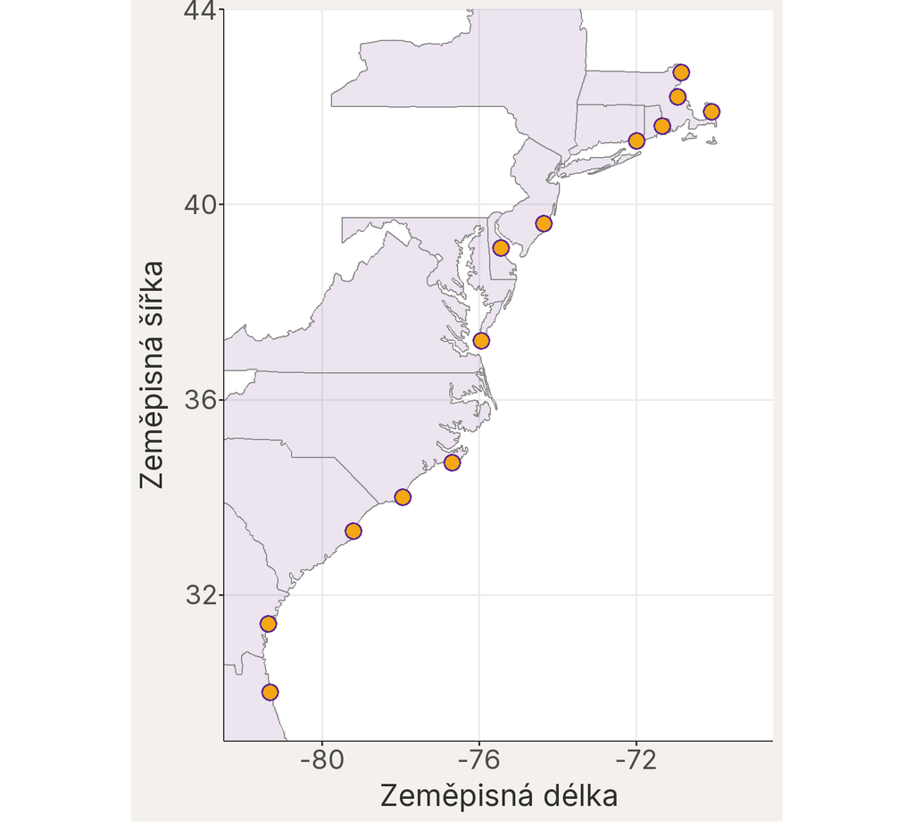

Každý oranžový bod představuje jedno sledované slanisko podél atlantského pobřeží USA. Souřadnice pocházejí z tabulky 1 související studie.

Při prvním čtení můžete následující dva boxy „Doplňující“ přeskočit. Hlavní krabí příběh pokračuje grafem průměrů a přímkou.

**TipDoplňující: odkud se vzaly průměry slanisek?**

Původní tabulka obsahuje 392 jednotlivých krabů. Pro hlavní analýzu jsme je zprůměrovali po lokalitách.

Data jsou přímo součástí balíčku `lterdatasampler`. Následující kód je načte, srozumitelně přejmenuje, vytvoří průměry slanisek, spojí je s počty změřených krabů a obě výukové tabulky uloží jako CSV. Díky tomu může hlavní část lekce začít jednoduchým `read.csv()` a nemusí přípravu opakovat při každém renderu.

```r
# Balíček stačí nainstalovat jednou:
# install.packages("lterdatasampler")

data("pie_crab", package = "lterdatasampler")

# Přejmenujeme sloupce tak, aby se s nimi v lekci dobře pracovalo.
data_krabi <-
  data.frame(
    datum = as.Date(x = pie_crab$date),
    zemepisna_sirka = pie_crab$latitude,
    kod_lokality = pie_crab$site,
    nazev_lokality = pie_crab$name,
    sirka_krunyre_mm = pie_crab$size
  )

# Pro každou lokalitu spočítáme průměrnou šířku krunýře.
data_prumery <-
  aggregate(
    x = sirka_krunyre_mm ~
      kod_lokality + nazev_lokality + zemepisna_sirka,
    data = data_krabi,
    FUN = mean
  )

# Zvlášť spočítáme počet změřených krabů na každé lokalitě.
data_pocty <-
  aggregate(
    x = sirka_krunyre_mm ~ kod_lokality,
    data = data_krabi,
    FUN = length
  )

# Obě souhrnné tabulky spojíme podle kódu lokality.
data_lokality <-
  merge(
    x = data_prumery,
    y = data_pocty,
    by = "kod_lokality",
    suffixes = c("_prumer", "_pocet")
  )

names(x = data_lokality)[
  names(x = data_lokality) == "sirka_krunyre_mm_prumer"
] <- "prumerna_sirka_mm"

names(x = data_lokality)[
  names(x = data_lokality) == "sirka_krunyre_mm_pocet"
] <- "pocet_krabu"

# Seřadíme lokality od jihu k severu a ponecháme potřebné sloupce.
data_lokality <-
  data_lokality[
    order(data_lokality$zemepisna_sirka),
    c(
      "kod_lokality",
      "nazev_lokality",
      "zemepisna_sirka",
      "pocet_krabu",
      "prumerna_sirka_mm"
    )
  ]

# Uložíme jednotlivé kraby i připravené průměry lokalit.
write.csv(
  x = data_krabi,
  file = "data/pie_crab.csv",
  row.names = FALSE
)

write.csv(
  x = data_lokality,
  file = "data/pie_crab_site_means.csv",
  row.names = FALSE
)
```

**TipDoplňující: jak vypadají všichni krabi?**

Na obrázku jsou jednotliví krabi světle šedě. Velké body jsou průměry slanisek, které používáme v modelu.

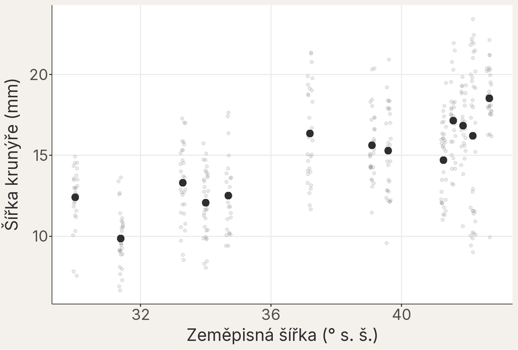

Jednotliví krabi sdílejí zeměpisnou šířku svého slaniska. Velké body zobrazují průměry použité v hlavním modelu.

V této lekci proto pracujeme se 13 průměry lokalit. Proč nelze jednotlivé kraby bez dalšího považovat za 392 nezávislých odpovědí na otázku o zeměpisné šířce, probereme později u hierarchických datData, kde pozorování nejsou zcela nezávislá - jsou seskupena do vyšší úrovně (lokality, bloky, jedinci s opakovanými měřeními)..

## 4 Co říká známá přímka?

**QuestionNež se podíváte — Jaký obrázek by podpořil naši domněnku?**

Než si hodnoty zobrazíte v grafu, načrtněte si očekávaný obrázek.

- Co bude na vodorovné ose?
- Co bude na svislé ose?
- Jak by měly body vypadat, kdyby byli krabi na severu větší?
- Jaký vzor by naopak mluvil proti této představě?

**DůležitéMožné odpovědi**

Na vodorovné ose bude prediktorProměnná, pomocí níž vysvětlujeme variabilitu odezvy; v notaci y ~ x je prediktor x. zeměpisná šířka, na svislé ose odezvaProměnná, jejíž variabilitu se snažíme vysvětlit nebo předpovědět; v notaci modelu y ~ x je odezva y. průměrná šířka krunýře. Kdyby byli krabi na severu větší, body by směrem doprava převážně stoupaly. Proti této představě by mluvily body, které doprava klesají nebo netvoří žádný zřetelný trend.

Teď už můžeme body opravdu zobrazit. Každý bod je průměrSoučet hodnot vydělený jejich počtem; nejběžnější míra polohy (střední hodnoty). jednoho slaniska.

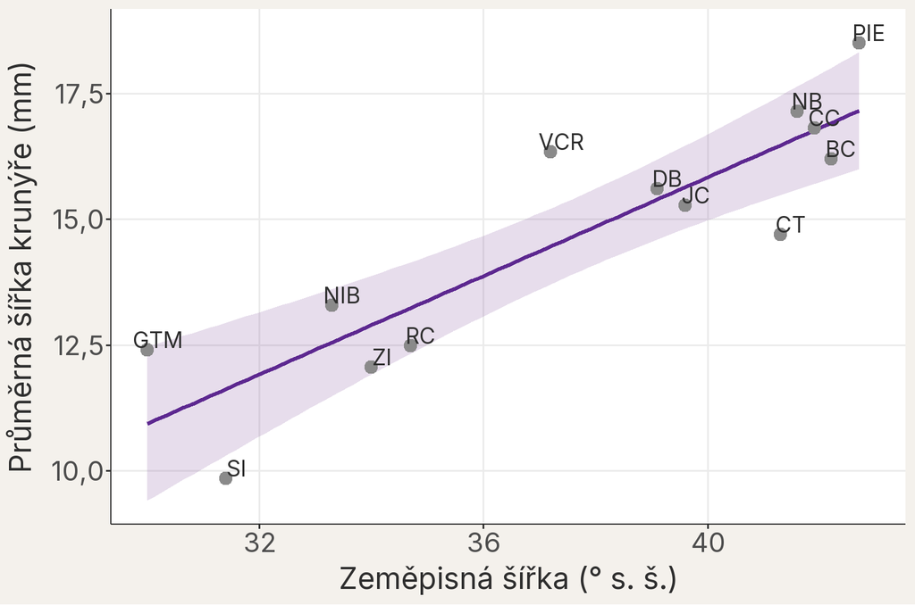

Průměrná šířka krunýře na sledovaných slaniskách. Fialová přímka je jednoduchý lineární model, světle fialový pás kolem ní jeho 95% pás spolehlivosti.

Body směrem doprava převážně stoupají. Na severnějších lokalitách tedy mají krabi v průměru širší krunýře. Přímku fitujeme stejným příkazem `lm()`, který už znáte:

```r
# Fitujeme přímku přes průměry slanisek
mod_krabi <-
  lm(
    formula = prumerna_sirka_mm ~ zemepisna_sirka,
    data = data_lokality
  )

# Zobrazíme celý přehled modelu.
summary(object = mod_krabi)
```

```
Call:
lm(formula = prumerna_sirka_mm ~ zemepisna_sirka, data = data_lokality)

Residuals:
     Min       1Q   Median       3Q      Max
-1.77895 -0.74796  0.05101  0.73779  1.87228

Coefficients:
                Estimate Std. Error t value Pr(>|t|)
(Intercept)     -3.74716    3.00884  -1.245    0.239
zemepisna_sirka  0.48953    0.07948   6.159 7.11e-05 ***
---
Signif. codes:  0 '***' 0.001 '**' 0.01 '*' 0.05 '.' 0.1 ' ' 1

Residual standard error: 1.226 on 11 degrees of freedom
Multiple R-squared:  0.7752,    Adjusted R-squared:  0.7548
F-statistic: 37.94 on 1 and 11 DF,  p-value: 7.112e-05
```

```r
# Zobrazíme 95% intervaly spolehlivosti obou koeficientů.
confint(object = mod_krabi)
```

```
                      2.5 %    97.5 %
(Intercept)     -10.3695640 2.8752446
zemepisna_sirka   0.3146022 0.6644593
```

V první tabulce už z předchozích lekcí umíme najít řádek se sklonemParametr lineárního modelu udávající, o kolik se v průměru liší odezva dvou pozorování, jejichž prediktor se liší o jednu jednotku (při stejných hodnotách ostatních prediktorů). (`zemepisna_sirka`). Ve sloupci `Estimate` je jeho odhadČíslo vypočtené z pozorovaných dat jako přiblížení neznámé vlastnosti nebo parametru; jiný srovnatelný výběr může dát jiný odhad. 0,490 mm na stupeň. Vedle něj je známá standardní chybaMíra přesnosti odhadu parametru (průměru, sklonu…); odhaduje z jediného výběru, jak moc by se odhady typicky lišily mezi opakovanými výběry stejné velikosti. 0,0795 mm na stupeň. Příkaz `confint()` pak ukazuje 95% intervalRozsah hodnot vypočtený z dat postupem, který při opakovaných výběrech pokryje skutečnou hodnotu parametru ve zvoleném podílu případů (typicky 95 %). od 0,315 do 0,664 mm na stupeň.

Model odhaduje také interceptParametr modelu: odhadnutá hodnota odezvy, když jsou všechny numerické prediktory rovny nule a kategoriální prediktory jsou v referenční skupině; geometricky jde o úsek na ose y.. Ten by zde popisoval šířku krabů na rovníku, daleko mimo sledovaný rozsah, a pro naši biologickou otázku není zajímavý. Sloupce `t value` a `Pr(>|t|)`, zmíněné v úvodu, zatím necháme stranou. Stranou necháme také hvězdičky u řádků (`Signif. codes`) a spodní řádky s R² a `F-statistic`; k nim se vrátíme v dalších lekcích.

**TipDoplňující: kód pro přímku s pásem spolehlivosti**

Pás spočítáme funkcí `predict()` s argumentem `interval = "confidence"` stejně jako v minulé lekci:

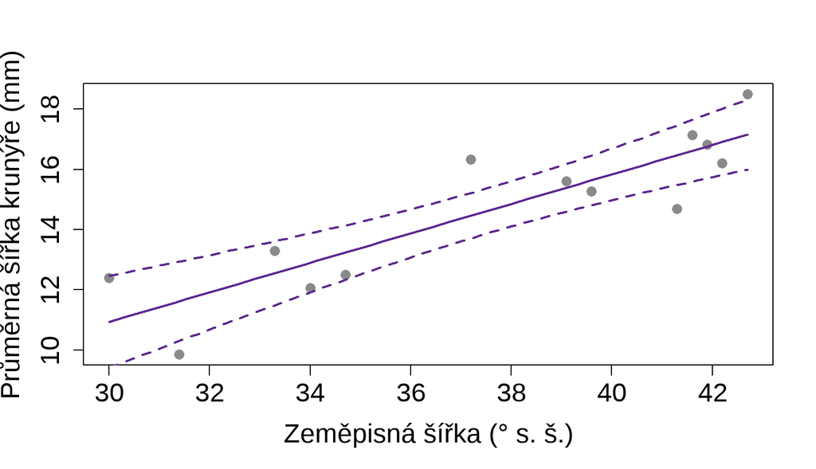

```r
# Padesát zeměpisných šířek od nejjižnější po nejsevernější lokalitu
data_mrizka <-
  data.frame(
    zemepisna_sirka = seq(
      from = min(data_lokality$zemepisna_sirka),
      to = max(data_lokality$zemepisna_sirka),
      length.out = 50
    )
  )

# Pro každou šířku odhad průměru (fit) a hranice intervalu (lwr, upr)
mat_pas <-
  predict(
    object = mod_krabi,
    newdata = data_mrizka,
    interval = "confidence"
  )

# Body slanisek
plot(
  x = data_lokality$zemepisna_sirka,
  y = data_lokality$prumerna_sirka_mm,
  xlab = "Zeměpisná šířka (° s. š.)",
  ylab = "Průměrná šířka krunýře (mm)",
  pch = 16,
  col = "#8A8A8A",
  cex = 1.3
)

# Odhadnutá přímka plnou čarou, hranice pásu přerušovaně
lines(
  x = data_mrizka$zemepisna_sirka,
  y = mat_pas[, "fit"],
  col = "#5D2890",
  lwd = 2
)
lines(
  x = data_mrizka$zemepisna_sirka,
  y = mat_pas[, "lwr"],
  col = "#5D2890",
  lty = 2,
  lwd = 2
)
lines(
  x = data_mrizka$zemepisna_sirka,
  y = mat_pas[, "upr"],
  col = "#5D2890",
  lty = 2,
  lwd = 2
)
```

### 4.1 Dobrá praxe: po každém modelu zkontrolujeme residua

Výpis koeficientůČíselné hodnoty odhadnuté z dat definující tvar modelu; v lineárním modelu jsou to intercept a sklon(y). není konec práce. Stejně jako v minulé lekci se hned po fitování modelu podíváme na residuaRozdíl mezi pozorovanou hodnotou odezvy a hodnotou odhadnutou modelem: eᵢ = yᵢ − ŷᵢ. — rozdíly mezi pozorovanými průměry lokalit a hodnotami na přímce. Tuto kontrolu budeme dělat pokaždé, když fitujeme lineární modelStatistický model, v němž je průměrná odezva součtem interceptu a prediktorů násobených koeficienty; lineární je v koeficientech, takže nemusí jít jen o přímku..

```r
# Z modelu získáme residua a hodnoty odhadnuté přímkou.
vec_residua_krabi <- resid(object = mod_krabi)
vec_odhadnute_hodnoty <- fitted(object = mod_krabi)
```

První graf je histogramGraf zobrazující rozdělení hodnot numerické proměnné: hodnoty jsou rozděleny do sousedních intervalů (košů), výška sloupce udává četnost v daném koši. residuí, který znáte z lekce o lineárním modelu. Hodnota nula znamená, že bod leží přesně na přímce; kladná a záporná residua leží na opačných stranách přímky.

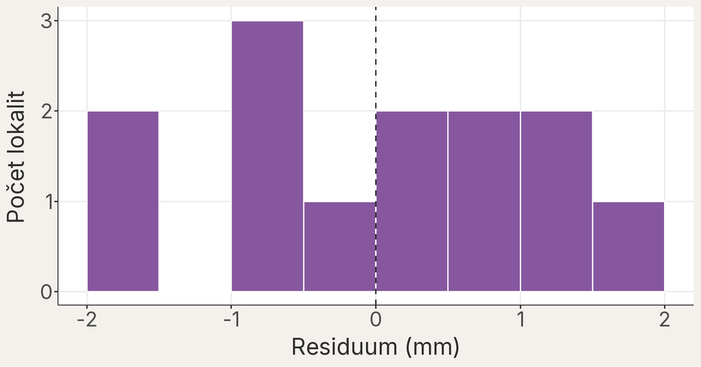

Histogram residuí krabího modelu. Každá lokalita přispívá do jednoho sloupce.

Tvar residuí podrobněji ukáže Q–Q grafGraf, který porovnává seřazené hodnoty (typicky residua) s kvantily očekávanými u zvoleného rozdělení, nejčastěji normálního., který známe z lekce o lineárním modelu. Seřazená residua porovnává s hodnotami, které bychom na stejném místě pořadí čekali u souměrného zvonovitého rozdělení. Body blízko přerušované přímky znamenají, že se tvar residuí od zvonovitého výrazně neliší.

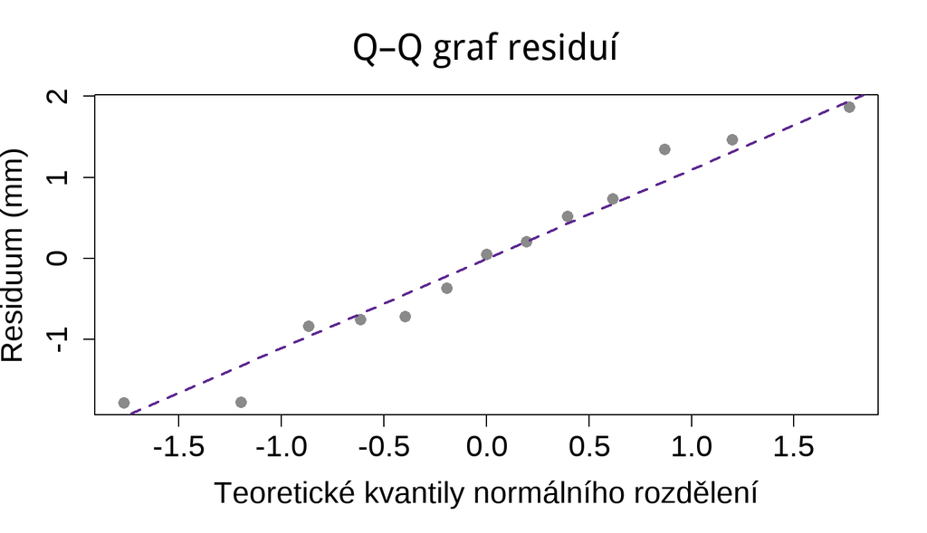

```r
qqnorm(
  # Seřazená residua porovnáme s kvantily normálního rozdělení
  y = vec_residua_krabi,
  main = "Q–Q graf residuí",
  xlab = "Teoretické kvantily normálního rozdělení",
  ylab = "Residuum (mm)",
  pch = 16,
  col = "#8A8A8A",
  cex = 1.3
)

qqline(
  # Referenční přímka prochází prvním a třetím kvartilem residuí
  y = vec_residua_krabi,
  lty = 2,
  lwd = 2,
  col = "#5D2890"
)
```

Další graf vrací každé residuum k hodnotě odhadnuté modelemHodnota odezvy, kterou fitovaný model přiřadí pozorování na základě jeho hodnot prediktorů; značí se často ŷ. pro danou lokalitu. Hledáme body rozptýlené kolem nuly bez zřetelného oblouku nebo vějíře.

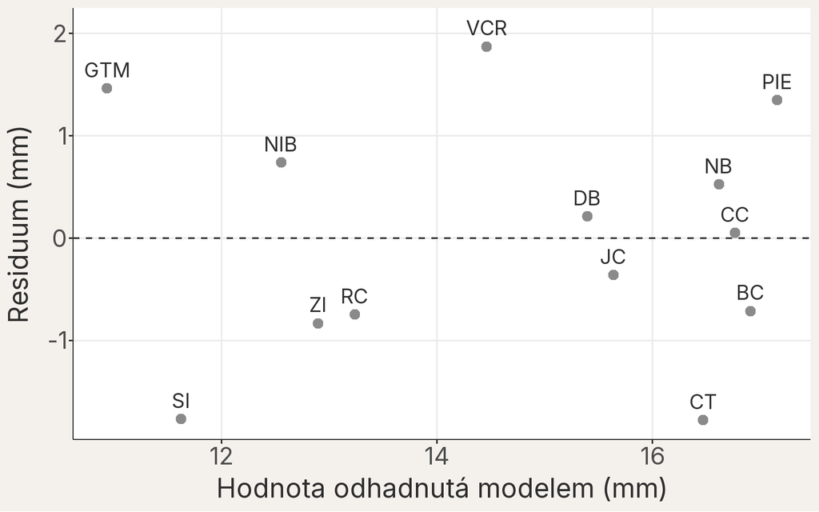

Residua proti hodnotám odhadnutým modelem. Popisky umožňují spojit neobvyklé residuum s konkrétní lokalitou.

**QuestionPřečtěte diagnostické grafy**

- Jsou kladná i záporná residua zastoupena kolem nuly?
- Leží body Q–Q grafu blízko přerušované přímky?
- Vidíte v grafu residuí proti odhadnutým hodnotám oblouk, vějíř nebo jiný systematický vzor?
- Které lokality mají největší residua?
- Co můžeme z tak malého počtu bodů posoudit jen velmi opatrně?

**DůležitéMožné odpovědi**

Kladná i záporná residua jsou zastoupena zhruba stejně a leží mezi -1,78 a 1,87 mm. Body Q–Q grafu leží blízko přímky a v grafu proti odhadnutým hodnotám nevidíme oblouk ani vějíř. Největší residua mají lokality VCR, CT, SI. Z 13 bodů ale nelze spolehlivě posoudit tvar rozdělení residuí; jeden nebo dva body navíc by histogram snadno změnily.

Grafy neukazují nápadný systematický vzor, ale 13 lokalit je málo pro sebevědomou diagnostikuSoubor grafických a numerických kontrol ověřujících, zda jsou rozumně splněny předpoklady modelu: linearita, nezávislost pozorování, konstantní rozptyl a normalita residuí, a zda závěr nestojí na několika vlivných pozorováních. tvaru rozdělení. Kontrola tedy neodhalila zřejmý problém; stále však musíme pamatovat na malý počet lokalit a jednoduchost modelu.

### 4.2 Nestojí přímka na jedné lokalitě?

Při tak malém počtu lokalit může jediné slanisko přímku výrazně naklonit. Proto přidáme kontrolu, kterou známe z minulých lekcí: Cookovu vzdálenostMíra vlivu jednoho pozorování na model: vyjadřuje, jak moc by se změnily odhadnuté hodnoty, kdybychom toto pozorování vynechali.. Pro každou lokalitu vyjadřuje, jak moc by se změnila přímka, kdybychom právě tuto lokalitu vynechali. Velkou hodnotu mívá lokalita, která má velké residuum a zároveň leží daleko od průměrné zeměpisné šířky, tedy má velký pákový efektMíra toho, jak neobvyklé hodnoty prediktorů má jedno pozorování ve srovnání s ostatními; nezávisí na naměřené odezvě..

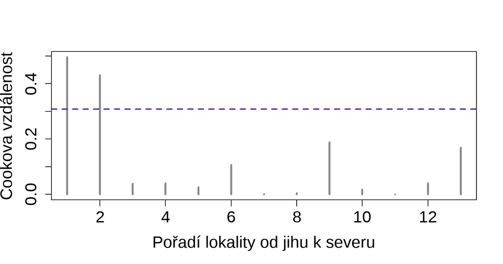

```r
# Cookova vzdálenost pro každou lokalitu (řádky jsou od jihu k severu)
vec_cookova_vzdalenost <-
  cooks.distance(model = mod_krabi)

plot(
  x = vec_cookova_vzdalenost,
  type = "h",
  lwd = 3,
  col = "#8A8A8A",
  xlab = "Pořadí lokality od jihu k severu",
  ylab = "Cookova vzdálenost"
)

abline(
  # Orientační hodnota 4/n, kde n je počet lokalit
  h = 4 / nrow(x = data_lokality),
  lty = 2,
  lwd = 2,
  col = "#5D2890"
)
```

```r
# Lokality nad orientační hodnotou 4/n
data_lokality$kod_lokality[
  vec_cookova_vzdalenost > 4 / nrow(x = data_lokality)
]
```

```
[1] "GTM" "SI"
```

Orientační hodnotu 4/n = 0,31 překračují lokality GTM a SI. Jsou to dvě nejjižnější slaniska: leží na okraji rozsahu zeměpisné šířky, a proto mají velký pákový efekt. Když model přepočítáme 13krát, pokaždé bez jedné lokality, změní se sklon nejvýš o 0,069 mm na stupeň, tedy asi o 87 % standardní chyby sklonu. Sklon přitom zůstává vždy kladný: přibližně od 0,429 do 0,559 mm na stupeň.

**QuestionZkuste si — Smažeme vlivné lokality?**

Spolužák navrhne lokality nad orientační čarou z dat vyřadit, „protože jsou vlivnéPozorování, jehož vynechání by výrazně změnilo odhadnutý model; vlivná bývají hlavně pozorování s velkým pákovým efektem i velkým residuem.“. Co mu odpovíte?

**DůležitéMožná odpověď**

Vysoká Cookova vzdálenost není důvod řádek smazat. Hodnota 4/n není test ani pravidlo pro mazání dat; jen upozorňuje, kterým lokalitám se máme podívat blíž. Lokality GTM a SI jsou pro otázku o zeměpisné šířce cenné, protože jako nejjižnější slaniska rozšiřují pozorovaný rozsah. Správný postup je ověřit jejich měření a porovnat závěr s nimi a bez nich: sklon zůstává kladný, takže závěr o směru vztahu na jediné lokalitě nestojí. Velikost změny ale připomíná, že s 13 lokalitami je odhad citlivý na to, která slaniska studie zahrnula.

Stejný modelový výsledek budeme dále číst podmíněně: všechny následující závěry o velikosti vztahu a nejistotěRozsah, v němž nevíme přesnou hodnotu parametru kvůli omezenému výběru a výběrové variabilitě; kvantifikuje se pomocí standardních chyb a intervalů spolehlivosti. předpokládají, že zvolená přímka, chování residuí a nezávislost lokalit jsou pro naši otázku přiměřené. Diagnostika nemůže dokázat správnost modelu, ale pomáhá odhalit zřetelný rozpor dříve, než začneme interpretovat další čísla z modelu.

### 4.3 Co znamená sklon v milimetrech na stupeň?

Sklon 0,490 mm na jeden stupeň říká:

**DůležitéVýznam sklonu v našem modelu**

Podle odhadnuté přímky je na lokalitě o 1° severněji průměrná šířka krunýře větší přibližně o 0,490 mm.

To je odpověď na otázku **„o kolik?“**. Takovému číselnému popisu změny říkáme **efektKvantitativní popis toho, jak se podle modelu mění odezva s prediktorem; zahrnuje směr, velikost a nejistotu odhadu, ale sám o sobě nedokládá příčinu.**; v tomto modelu ho nejlépe vyjadřuje sklon v milimetrech na stupeň. V dalších krocích se budeme ptát, jak přesný odhad je a jak neobvyklý by byl, kdyby ve skutečnosti žádný vztah neexistoval.

Změna o 0,49 mm na jeden stupeň se těžko představuje. Co by takový sklon znamenal při cestě o 5 stupňů na sever? A co mezi Floridou a Massachusetts?

- na 1°: 0,490 mm;
- na 5°: 2,45 mm;
- přes celý pozorovaný rozsah 12,7°: 6,22 mm.

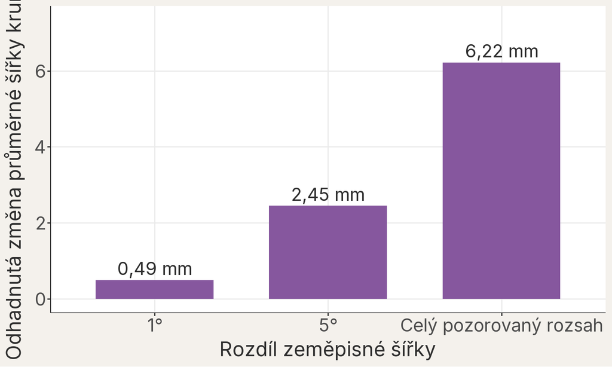

Tentýž sklon přepočtený na 1°, na zvolený větší rozdíl a na celý rozsah sledovaných zeměpisných šířek.

Průměrné šířky krunýře se na slaniskách pohybují přibližně mezi 9,9 a 18,5 mm.

**QuestionZkuste si — Je to biologicky hodně?**

1. Které měřítko se vám interpretuje nejsnáze: 1°, 5°, nebo celý rozsah?
2. Je změna přibližně 6,22 mm velká vzhledem k šířce krabů v tabulce?
3. Jakou další biologickou informaci byste potřebovali, abyste význam rozdílu posoudili lépe?
4. Mohla by studie najít velmi přesně změnu, která je biologicky zanedbatelná?

**DůležitéMožné odpovědi**

Přes celé sledované pobřeží odpovídá sklon změně asi 6,22 mm, tedy zhruba 42 % průměrné šířky krunýře. Takový rozdíl lze v terénu změřit a může souviset například s plodností nebo soubojem samců. K lepšímu posouzení bychom potřebovali vědět, jak velké rozdíly ve velikosti mají pro kraby biologické důsledky. A ano: velmi přesná studie, třeba s tisíci lokalitami, může přesně odhadnout i změnu, která je biologicky zanedbatelná.

## 5 Jeden odhad nestačí

SklonParametr lineárního modelu udávající, o kolik se v průměru liší odezva dvou pozorování, jejichž prediktor se liší o jednu jednotku (při stejných hodnotách ostatních prediktorů). 0,490 mm na stupeň je náš nejlepší bodový odhadČíslo vypočtené z pozorovaných dat jako přiblížení neznámé vlastnosti nebo parametru; jiný srovnatelný výběr může dát jiný odhad.. Naše slaniska ale nejsou jediná, která jsme mohli navštívit. Jiný výběrSoubor pozorování, z něhož počítáme statistiky a pomocí něhož se snažíme popsat širší populaci nebo proces. by nejspíš dal trochu jiný sklon.

Právě proto jsme se v minulé lekci učili číst standardní chybuMíra přesnosti odhadu parametru (průměru, sklonu…); odhaduje z jediného výběru, jak moc by se odhady typicky lišily mezi opakovanými výběry stejné velikosti. a interval spolehlivostiRozsah hodnot vypočtený z dat postupem, který při opakovaných výběrech pokryje skutečnou hodnotu parametru ve zvoleném podílu případů (typicky 95 %)..

U krabího sklonu máme:

- odhad 0,490 mm na stupeň;
- standardní chybu 0,0795 mm na stupeň;
- 95% interval od 0,315 do 0,664 mm na stupeň.

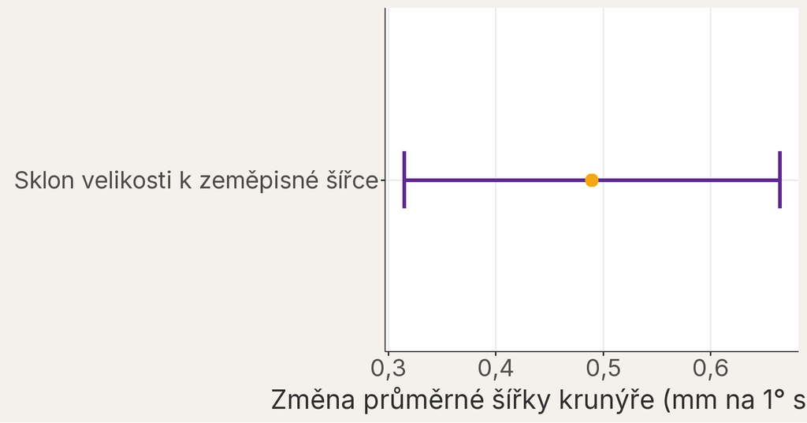

Odhad sklonu a jeho 95% interval spolehlivosti.

**QuestionZastavte se u obrázku — Co všechno ještě připouští interval?**

- Kde leží bodový odhad?
- Jaké malé i velké změny připouští celý interval?
- Jsou všechny biologicky stejně zajímavé?
- Co by pro naše sebevědomí znamenal mnohem širší interval?

**DůležitéMožné odpovědi**

Bodový odhad leží na 0,490 mm na stupeň. Interval připouští pomalejší růst kolem 0,31 mm na stupeň (asi 1,57 mm na 5°) i rychlejší růst kolem 0,66 mm na stupeň (asi 3,32 mm na 5°). Pomalejší růst by byl biologicky méně zajímavý než rychlejší. Mnohem širší interval by připouštěl mnohem širší rozpětí velikostí vztahu, možná i nulu nebo pokles, a o velikosti vztahu bychom si byli mnohem méně jistí.

Všechny hodnoty v intervalu popisují růst velikosti směrem na sever. Liší se v tom, jak rychlý by tento růst mohl být.

## 6 Co kdyby ve skutečnosti žádný trend nebyl?

Z modelu už známe velikost vztahu i nejistotuRozsah, v němž nevíme přesnou hodnotu parametru kvůli omezenému výběru a výběrové variabilitě; kvantifikuje se pomocí standardních chyb a intervalů spolehlivosti. odhaduČíslo vypočtené z pozorovaných dat jako přiblížení neznámé vlastnosti nebo parametru; jiný srovnatelný výběr může dát jiný odhad.. K našemu výsledku teď postavíme jedno přesné soupeřící tvrzení.

Představte si skeptickou kolegyni. Podívá se na graf a řekne:

**TipNámitka skeptické kolegyně**

„Možná mezi zeměpisnou šířkou a průměrnou velikostíSoučet hodnot vydělený jejich počtem; nejběžnější míra polohy (střední hodnoty). krabů v populaciCelá množina jednotek nebo širší proces, o kterém chceme pomocí výběru něco zjistit; její vlastnosti (parametry) obvykle neznáme. žádný lineární vztah není. Těchto 13 bodů náhodou vyšlo rostoucích.“

Tady se vracíme k otázce z úvodu: jaké pozorování by nás přimělo změnit názor? Kolegyně nabízí konkrétní tvrzení a my se můžeme ptát, jak dobře se s ním naše data shodují.

Svět bez trendu nemůžeme navštívit a nemůžeme v něm zopakovat terénní výzkum. Můžeme si ho ale představit tak přesně, že ho dokážeme **vytvořit v počítači**. Stačí popsat, jak by v takovém světě vznikala data. Potom můžeme vytvořit tisíce takových „nulových světů“, v každém fitovat přímku stejně jako u skutečných dat a podívat se, jak často by v nich vyšel sklon podobný našemu.

Jak by takový svět vypadal v našem modelu? Kdyby měla přímka sklonParametr lineárního modelu udávající, o kolik se v průměru liší odezva dvou pozorování, jejichž prediktor se liší o jednu jednotku (při stejných hodnotách ostatních prediktorů). **nula**, průměrná velikost krabů by se při cestě na sever neměnila. To ale neznamená, že by všechny lokality měly úplně stejný průměr.

I ve světě bez severojižního trendu by mezi lokalitami zůstávaly rozdíly. Mohly by vznikat například:

- náhodným výběremVýběr, v němž má každá jednotka populace známou (typicky stejnou) šanci být vybrána; jen u takového výběru lze výsledky zobecnit bez dalších předpokladů. jiných krabů;
- nepřesností měření;
- místními podmínkami, které v modelu nemáme, třeba potravou nebo teplotou;
- dalšími biologickými rozdíly mezi slanisky.

SimulovanáOpakované vytváření umělých dat podle známého modelu na počítači; ukazuje, jak se odhady, intervaly nebo testy chovají napříč mnoha výběry. data proto poskládáme ze dvou částí:

1. **Systematická část:** vodorovná přímka se sklonem nula. Všechny zeměpisné šířky mají stejnou očekávanou průměrnou velikost.
2. **Náhodná část:** náhodná variabilitaObecný termín pro rozsah, v němž se hodnoty proměnné liší od sebe navzájem; kvantifikuje se pomocí rozptylu, SD, IQR nebo rozsahu. kolem této přímky. V simulaci zastupuje všechny přirozené procesy ze seznamu výše.

Náhodnou část už známe z diagnostiky modeluSoubor grafických a numerických kontrol ověřujících, zda jsou rozumně splněny předpoklady modelu: linearita, nezávislost pozorování, konstantní rozptyl a normalita residuí, a zda závěr nestojí na několika vlivných pozorováních.. Rozdíl mezi hodnotou lokality a hodnotou na přímce jsme nazvali residuumRozdíl mezi pozorovanou hodnotou odezvy a hodnotou odhadnutou modelem: eᵢ = yᵢ − ŷᵢ.. V simulaci ke každé lokalitě vytvoříme nové náhodné residuum a přičteme ho k vodorovné přímce. **Takové residuum není chyba ve výpočtu. Napodobuje přirozené procesy, kvůli kterým se skutečná slaniska liší, i když žádný trend neexistuje.** Simulovaná residua budou v průměru nulová, ale jednotlivě mohou být kladná i záporná.

Jak velká mají simulovaná residua být? Stejně velká jako residua kolem skutečné krabí přímky. Jejich typickou velikost popisuje residuální směrodatná odchylkaOdhad typické velikosti residuí v jednotkách odezvy; popisuje rozptýlení pozorování kolem hodnot odhadnutých modelem., kterou jsme poznali v minulé lekci. Už ji máme před sebou: ve výpisu `summary(mod_krabi)` z oddílu „Co říká známá přímka?“ je to řádek hned pod tabulkou koeficientů:

```
Residual standard error: 1.226 on 11 degrees of freedom
```

Je to obdoba směrodatné odchylkyOdmocnina rozptylu; vyjadřuje typickou vzdálenost hodnot od průměru ve stejných jednotkách jako původní data.: neměří ale vzdálenosti hodnot od průměru, nýbrž vzdálenosti bodů od přímky, tedy velikost residuí. U krabího modelu vychází přibližně 1,23 mm. Průměr typického slaniska tedy leží zhruba 1,23 mm nad přímkou nebo pod ní; blíž než tato hodnota leží 8 z 13 lokalit.

Právě tato simulovaná residua způsobí, že přímka odhadnutá z jednoho náhodného výběru nemusí vyjít přesně vodorovná — stejně jako skutečná residua způsobují, že pozorované body neleží přesně na odhadnuté přímce.

Porovnáváme tedy dva scénáře:

| Scénář | Co říká o krabech |
| --- | --- |
| Nulový scénář | Průměrná velikost se se zeměpisnou šířkou lineárně nemění. Sklon **je** 0 mm na stupeň. |
| Alternativní scénář | Průměrná velikost se se zeměpisnou šířkou lineárně mění. Sklon **není** 0 mm na stupeň. |

Nula se zde nevzala z obecného statistického pravidla. Patří k naší konkrétní otázce: v lineárním modeluStatistický model, v němž je průměrná odezva součtem interceptu a prediktorů násobených koeficienty; lineární je v koeficientech, takže nemusí jít jen o přímku. znamená sklon 0 přesně **žádnou změnu průměrné velikosti při cestě na sever**.

Oba scénáře mluví o sklonu v širší populaci lokalit, nikoli jen o našich 13 slaniskách. Odhadnutý sklon $b$ z našich dat se od populačního sklonu kvůli náhodné variabilitě může lišit. Tutéž dvojici můžeme zapsat zkráceně:

$$H_0:\ \text{sklon v populaci}=0
\qquad\text{a}\qquad
H_A:\ \text{sklon v populaci}\ne0$$

**Nulová hypotézaVýchozí předpoklad, který testujeme - typicky ‘efekt je nulový’ nebo ‘skupiny se neliší’; p-hodnota udává pravděpodobnost dat alespoň tak extrémních jako naše za předpokladu platnosti H₀.** $H_0$ je právě nulový scénář z tabulky. **Alternativní hypotézaTvrzení, které připouští to, co nulová hypotéza vylučuje - typicky ‘efekt není nulový’ nebo ‘skupiny se liší’; značí se H_A.** $H_A$ připouští růst i pokles.

Nulová hypotéza tedy **neříká**, že každý soubor 13 slanisek musí dát odhad sklonu přesně nula. Říká, že dlouhodobý systematický trend je nulový. Náhodná variabilita kolem něj může v jednotlivém souboru vytvořit mírně rostoucí i mírně klesající přímku.

Tento nulový svět teď prozkoumáme simulacíOpakované vytváření umělých dat podle známého modelu na počítači; ukazuje, jak se odhady, intervaly nebo testy chovají napříč mnoha výběry.. Ponecháme stejné zeměpisné šířky jako v našich datech. Pro každou z nich vygenerujeme průměrnou velikost jako **stejnou základní úroveň plus nové náhodné residuum**. V simulaci tedy není žádný systematický růst k severu, ale lokality se stále liší. Každému novému souboru potom fitujeme přímku.

**QuestionPředpovězte výsledek simulace**

- Budou všechny odhadnuté sklony přesně nulové?
- Kolem jaké hodnoty se budou shlukovat?
- Mohou občas vzniknout i výrazně kladné nebo záporné sklony?
- Kam by asi patřil náš sklon 0,490 mm na stupeň?

**DůležitéMožné odpovědi**

Odhadnuté sklony nebudou přesně nulové, protože každý simulovaný soubor dostane jiná náhodná residua. Budou se ale shlukovat kolem nuly, protože do simulace žádný trend nevkládáme. Občas vznikne i výraznější kladný nebo záporný sklon, ale čím dál od nuly, tím vzácněji. Zda patří náš sklon mezi běžné, nebo velmi vzácné výsledky, ukážou následující obrázky.

Zkusme si taková data vyrobit. Všechny lokality dostanou stejnou očekávanou velikost, takže vložený sklon je nula. Ke každé lokalitě ale přidáme nové náhodné residuum podobně velké jako residua kolem skutečné krabí přímky. Toto residuum v simulaci zastupuje přirozené rozdíly mezi slanisky: jiný výběr krabů, nepřesnost měření a místní podmínky. Začneme 20 takovými náhodnými studiemi.

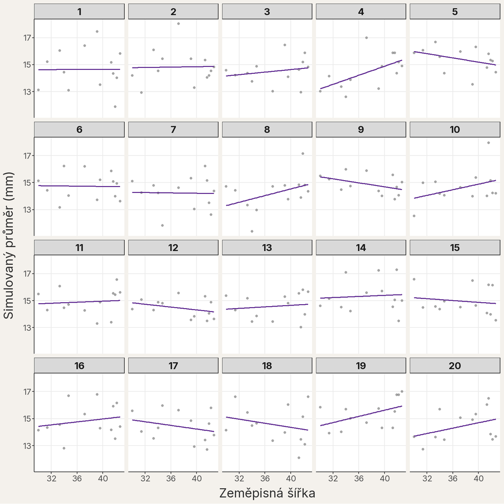

20 náhodných studií vytvořených ve světě s nulovým sklonem. Od vodorovné přímky jsme ke každé lokalitě přičetli nové náhodné residuum. Každá studie obsahuje stejný počet bodů jako naše data a vlastní odhadnutou přímku.

Přestože jsme žádný trend nevložili, některé přímky stoupají a jiné klesají. Náhoda tedy dokáže vytvořit nenulový odhad. Stejnou studii zopakujeme 5 000krát a z každé si ponecháme jen odhadnutý sklon.

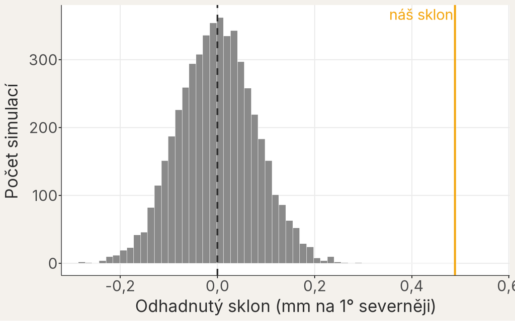

Sklony z 5 000 simulovaných souborů, ve kterých byl skutečný sklon nulový. Šedá čárkovaná čára označuje nulu, oranžová pozorovaný sklon.

Většina sklonů leží blízko nuly. Náš pozorovaný sklon je daleko vpravo. Abychom mohli říct **jak daleko**, potřebujeme vzdálenost vyjádřit vzhledem k nejistotě odhadu.

## 7 Jak daleko jsme od vodorovné přímky?

Nejprve si sepíšeme známá čísla:

| Co známe | Hodnota |
| --- | --- |
| Pozorovaný sklon (Estimate) | 0,490 mm na 1° |
| Sklon vodorovné přímky (nulová hodnota) | 0 mm na 1° |
| Rozdíl od nuly (Estimate − nulová hodnota) | 0,490 mm na 1° |
| Standardní chyba sklonu (Std. Error) | 0,0795 mm na 1° |

Otázka zní: **Kolikrát se standardní chybaMíra přesnosti odhadu parametru (průměru, sklonu…); odhaduje z jediného výběru, jak moc by se odhady typicky lišily mezi opakovanými výběry stejné velikosti. vejde do vzdálenosti mezi naším sklonemParametr lineárního modelu udávající, o kolik se v průměru liší odezva dvou pozorování, jejichž prediktor se liší o jednu jednotku (při stejných hodnotách ostatních prediktorů). a nulou?**

$$\frac{
\text{pozorovaný sklon}-\text{nulový sklon}
}{
\text{standardní chyba sklonu}
}$$

Dosadíme:

$$\frac{
\text{0,490}-0
}{
\text{0,0795}
}
\approx
\text{6,16}.$$

Náš sklon tedy leží přibližně 6,16 standardních chyb od nuly.

Statistici tuto vzdálenost označují písmenem $t$. Stejný výpočet se obecně zapisuje:

$$t=
\frac{
b-0
}{
\operatorname{SE}(b)
}.$$

Symbol $b$ označuje stejně jako v předchozích lekcích odhadnutýČíslo vypočtené z pozorovaných dat jako přiblížení neznámé vlastnosti nebo parametru; jiný srovnatelný výběr může dát jiný odhad. sklon, zde z řádku `zemepisna_sirka`. Nula je hodnota sklonu v populaci podle nulové hypotézyVýchozí předpoklad, který testujeme - typicky ‘efekt je nulový’ nebo ‘skupiny se neliší’; p-hodnota udává pravděpodobnost dat alespoň tak extrémních jako naše za předpokladu platnosti H₀. a $\operatorname{SE}(b)$ standardní chyba odhadu sklonu. Výslednému číslu se říká **t-statistikaTestová statistika: rozdíl odhadu od hodnoty v nulové hypotéze (obvykle 0) vydělený standardní chybou; říká, o kolik standardních chyb je odhad od nuly.**. Je to **testová statistikaČíslo vypočtené z dat, které porovnáváme s referenčním rozdělením platným při nulové hypotéze; z tohoto porovnání získáme p-hodnotu.**: číslo vypočtené z dat, které porovnáme s hodnotami, jaké by vznikaly, kdyby platila nulová hypotéza.

**QuestionZkuste si — Co by se s t stalo?**

1. Jak by se změnilo $t$, kdyby byl odhadnutý sklon stejný, ale standardní chyba dvakrát větší?
2. Jak by se změnilo $t$, kdyby měla studie stejnou standardní chybu, ale poloviční sklon?
3. Vysvětlete, proč t-statistika není velikostí biologického efektuKvantitativní popis toho, jak se podle modelu mění odezva s prediktorem; zahrnuje směr, velikost a nejistotu odhadu, ale sám o sobě nedokládá příčinu..

**DůležitéMožné odpovědi**

Při dvakrát větší standardní chybě by se $t$ zmenšilo na polovinu, přibližně na 3,08: stejný sklon by ležel jen o polovinu tolika standardních chyb od nuly. Poloviční sklon se stejnou standardní chybou by dal také přibližně 3,08. Stejné $t$ tedy může vzniknout z různých kombinací velikosti sklonu a přesnosti odhadu. T-statistika nemá jednotky milimetrů na stupeň. Stejné $t$ může vzniknout z malého sklonu, který je odhadnut velmi přesně, i z velkého sklonu s velkou standardní chybou. O biologické velikosti vztahu proto vypovídá sklon, ne $t$.

T-statistika je **standardizovaná vzdálenost od jedné konkrétní hodnoty**. Velké $|t|$ může vzniknout velkým efektem, vysokou přesností, nebo obojím.

## 8 Malá odbočka: kolik volnosti zbývá?

Stejná hodnota $t$ není stejně neobvyklá ve studii se čtyřmi body a ve studii se čtyřmi tisíci body. Při malém množství informace odhadujeme šum méně stabilně a musíme být opatrnější.

Tuto „zbývající informaci“ popisují **stupně volnostiPočet nezávislých informací dostupných pro odhad parametru; počet pozorování minus počet odhadovaných parametrů.** (anglicky *degrees of freedom*, zkratka **df**). V minulé lekci jsme je jen zmínili u kritické hodnotyNásobitel standardní chyby použitý při konstrukci intervalu, nebo hranice testové statistiky v testu; závisí na hladině, stupních volnosti a zvoleném rozdělení. intervalu spolehlivosti a slíbili, že je vysvětlíme. Zjednodušeně říkají, kolik hodnot v datech může ještě volně kolísat poté, co jsme z dat něco odhadli.

### 8.1 Sudoku: kdy poslední volba přestane být volbou

Co znamená „volně kolísat“, si nejprve ukážeme na hlavolamu Sudoku. Sudoku je hlavolam s mřížkou 9 × 9 polí. Mřížka je rozdělena na devět menších čtverců 3 × 3. Číslice 1 až 9 se musí objevit právě jednou v každém řádku, sloupci i malém čtverci.

Podívejme se jen na jeden čtverec 3 × 3. Vlevo známe tři číslice a pro prázdná pole ještě zbývá mnoho možností. Vpravo už jsou umístěny číslice 1 až 8. Poslední pole nemá na výběr: musí v něm být 9.

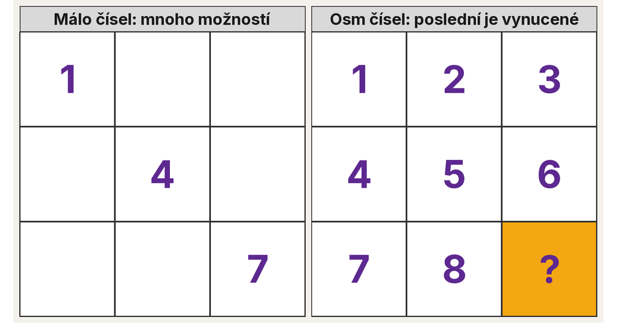

V neúplném čtverci zbývá mnoho možností. Po umístění osmi různých číslic je poslední hodnota vynucená.

Stupně volnosti jsou trochu podobné této situaci v Sudoku: říkají nám, **kolik volnosti k volbě ještě zbývá**, když už platí určitá omezení. Sudoku tuto myšlenku dobře zviditelní, i když jeho pravidla nejsou statistickým výpočtem.

### 8.2 Čtyři čísla s průměrem 10

Požadovaný součet získáme jako **počet čísel krát jejich pevný průměr**. Chceme 4 čísla s průměremSoučet hodnot vydělený jejich počtem; nejběžnější míra polohy (střední hodnoty). 10, takže jejich součet musí být 4 krát 10, tedy 40.

$$\text{požadovaný součet}
=
\text{počet čísel}
\times
\text{pevný průměr}.$$

Zvolme tři čísla. Poslední už musí doplnit součet do 40:

$$7+12+9+x=40$$

$$x=40-7-12-9=12.$$

Co když známe jen první dvě čísla?

$$7+12+x+y=40$$

Teď neznáme ani $x$, ani $y$. Z jediné rovnice je neumíme oba určit: $x$ si ještě můžeme zvolit a tím je $y$ vynuceno tak, aby součet zůstal 40. Ve srovnání s prvním příkladem tedy zbývá **o jednu volbu více**.

Nejde nám o vyřešení rovnice. Sledujeme, kolik hodnot ještě můžeme zvolit nezávisle a kolik jich už musí splnit omezení pevného součtu.

**QuestionZkuste vlastní čtveřici**

Napište tři libovolná čísla a sestavte rovnici pro čtvrté tak, aby jejich průměr byl 10. Kolik hodnot jste mohli zvolit nezávisle? Která hodnota už byla vynucená?

**DůležitéMožná odpověď**

Například čísla 5, 15 a 8 dávají rovnici $5+15+8+x=40$, takže $x=12$. Nezávisle jste mohli zvolit tři hodnoty, ať byly jakékoli. Čtvrtá už byla vynucená: musela doplnit součet do 40.

Pro 4 čísla s pevným průměrem platí:

$$\text{stupně volnosti}
=
\text{počet čísel}
-
\text{jedno omezení}$$

$$df=4-1=3.$$

První tři čísla mohou být zvolena volně. Jakmile známe je a požadovaný průměr, čtvrté musí doplnit součet do 40.

Obecně pro $n$ čísel s jedním pevným průměrem platí:

$$df=n-1,$$

kde $n$ je počet čísel a jednička představuje jedno omezení jejich součtu.

### 8.3 Zpět ke krabům

Krabí model má 13 průměrů slanisek. To je náš počet pozorováníJeden zaznamenaný případ v datech, který obsahuje hodnoty jedné nebo více proměnných.. Z těchto pozorování model odhaduje 2 hodnoty:

- interceptParametr modelu: odhadnutá hodnota odezvy, když jsou všechny numerické prediktory rovny nule a kategoriální prediktory jsou v referenční skupině; geometricky jde o úsek na ose y.;
- sklonParametr lineárního modelu udávající, o kolik se v průměru liší odezva dvou pozorování, jejichž prediktor se liší o jednu jednotku (při stejných hodnotách ostatních prediktorů)..

Po odhaduČíslo vypočtené z pozorovaných dat jako přiblížení neznámé vlastnosti nebo parametru; jiný srovnatelný výběr může dát jiný odhad. těchto 2 koeficientůČíselné hodnoty odhadnuté z dat definující tvar modelu; v lineárním modelu jsou to intercept a sklon(y). zbývá:

$$\text{residuální stupně volnosti}
=
\text{počet pozorování (zde počet lokalit)}
-
\text{počet odhadnutých koeficientů}$$

$$df=13-2=11.$$

Stejný vztah můžeme pro lineární modelStatistický model, v němž je průměrná odezva součtem interceptu a prediktorů násobených koeficienty; lineární je v koeficientech, takže nemusí jít jen o přímku. zapsat obecně:

$$df_{\mathrm{res}}=n-k,$$

kde $n$ je počet pozorování — u krabů počet lokalit — a $k$ je počet koeficientů odhadnutých z těchto pozorování. Zde tedy $n=13$ a $k=2$.

**QuestionSpojte tři pohledy — Kde přesně analogie končí?**

Doplňte tři věty:

1. Sudoku ukazuje, že …
2. Příklad s pevným průměrem ukazuje přesněji, že …
3. V regresi odhad interceptu a sklonu znamená, že …

**DůležitéMožné odpovědi**

1. Sudoku ukazuje, že po splnění pravidel může poslední volba přestat být volbou.
2. Příklad s pevným průměrem ukazuje přesněji, že jedno omezení součtu spotřebuje jeden stupeň volnosti.
3. V regresi odhad interceptu a sklonu znamená, že dva stupně volnosti spotřebujeme na tyto dva koeficienty a pro residuaRozdíl mezi pozorovanou hodnotou odezvy a hodnotou odhadnutou modelem: eᵢ = yᵢ − ŷᵢ. jich zbývá $n-2$.

Analogie končí tam, kde Sudoku vynucuje přesnou číslici. V regresi residua vynucená nejsou; stupně volnosti jen říkají, kolik nezávislé informace o jejich rozptýlení zbývá.

Teď si spojme počet pozorování s tím, kolik volnosti po fitování přímky zbývá. Přímka pokaždé odhaduje 2 koeficienty, intercept a sklon:

| Počet nezávislých pozorování | Odhadnuté koeficienty | Zbývající residuální df |
| --- | --- | --- |
| 3 | 2 | 1 |
| 13 | 2 | 11 |
| 10 002 | 2 | 10 000 |

Sudoku ukázalo volnost, která zbývá při postupném doplňování hodnot. Příklad s pevným průměrem ukázal stejnou myšlenku přesnou rovnicí. V regresi spotřebujeme část informace na odhad interceptu a sklonu. Když přidáme další nezávislá pozorování, ale stále odhadujeme jen tyto dva koeficienty, zbývá více residuálních stupňů volnosti.

### 8.4 Proč jsme s malým počtem lokalit opatrnější?

Vraťme se na chvíli ke krabům. Spočítali jsme, že pozorovaný sklon leží přibližně 6,16 standardních chybMíra přesnosti odhadu parametru (průměru, sklonu…); odhaduje z jediného výběru, jak moc by se odhady typicky lišily mezi opakovanými výběry stejné velikosti. od nuly, tedy $t\approx \text{6,16}$. Zatím ale nevíme, zda je to hodně. Potřebujeme vědět, jaké hodnoty $t$ by vznikaly ve světě s nulovým sklonem.

Takový svět jsme už vytvořili simulacíOpakované vytváření umělých dat podle známého modelu na počítači; ukazuje, jak se odhady, intervaly nebo testy chovají napříč mnoha výběry. a histogramGraf zobrazující rozdělení hodnot numerické proměnné: hodnoty jsou rozděleny do sousedních intervalů (košů), výška sloupce udává četnost v daném koši. ukázal, jak často v něm vycházely různé sklony. Kdybychom v každé simulované studii místo sklonu uložili jeho t-statistikuTestová statistika: rozdíl odhadu od hodnoty v nulové hypotéze (obvykle 0) vydělený standardní chybou; říká, o kolik standardních chyb je odhad od nuly., dostali bychom podobný histogram hodnot $t$. Nemusíme ho ale pokaždé simulovat. Statistici tvar tohoto histogramu znají předem a popisují ho hladkou křivkou, které se říká **t-rozděleníSouměrné rozdělení podobné normálnímu, ale s těžšími chvosty; jeho tvar určují stupně volnosti a používá se pro t-statistiku a intervaly spolehlivosti.**. Rozdělení, se kterým porovnáváme testovou statistiku a které platí, kdyby byla pravdivá nulová hypotéza, se obecně nazývá **referenční rozdělení**. Přesný tvar křivky závisí právě na stupních volnosti.

Křivka ukazuje, které hodnoty $t$ bychom při opakování studie čekali častěji a které méně často. **Celá plocha pod křivkou představuje všechny možné výsledky dohromady.**

Vyberme si dobře viditelnou hranici: hodnoty alespoň 2 standardní chybyMíra přesnosti odhadu parametru (průměru, sklonu…); odhaduje z jediného výběru, jak moc by se odhady typicky lišily mezi opakovanými výběry stejné velikosti. od nuly, tedy $t\leq-2$ nebo $t\geq2$. Fialová plocha ukáže, jak velká část možných výsledků leží za těmito hranicemi.

**TipPouze ilustrační příklad — ještě ne krabí výsledek**

Hodnotu $|t|=2$ jsme zvolili jen proto, aby byly vybarvené plochy dobře vidět. **Není to naše krabí t-statistika ani výsledek krabího modelu.** Obrázek zatím slouží pouze k porovnání ploch při různých stupních volnosti. Co přesně tato plocha znamená, pojmenujeme v následující části.

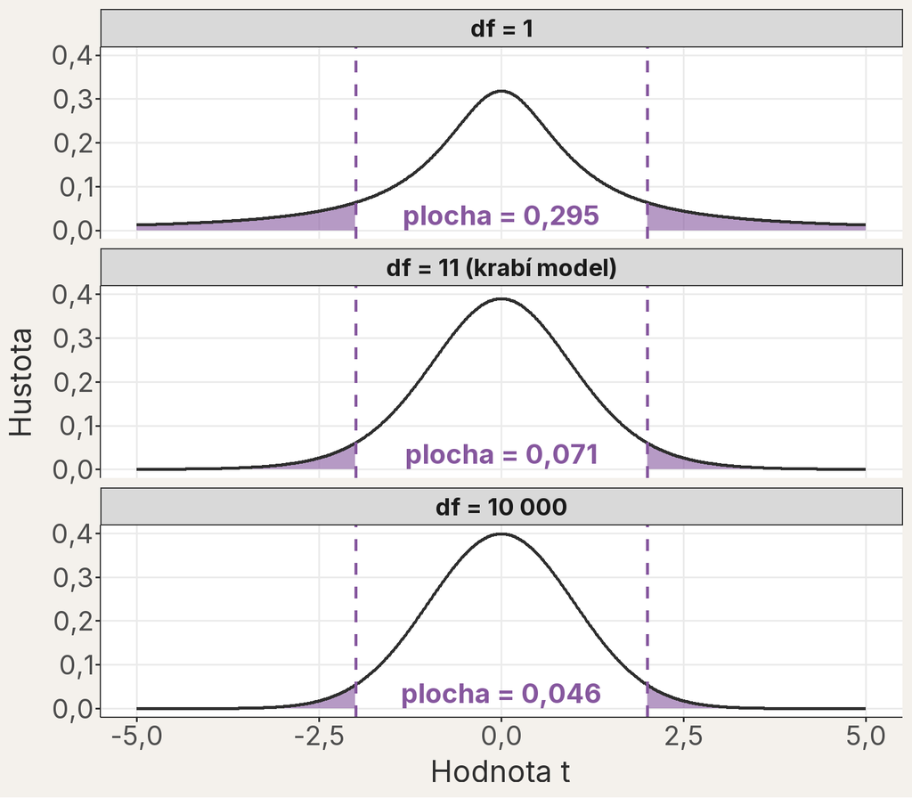

Tři t-křivky s různým počtem stupňů volnosti, df = 1 (nahoře), df = 11 jako u krabího modelu (uprostřed) a df = 10 000 (dole). Všechny tři mají stejné ilustrační hranice t = -2 a t = 2, které nejsou výsledkem krabího modelu.

**QuestionPřečtěte plochu pod křivkou**

- Co představuje celá plocha pod jednou křivkou?
- Co představují dvě fialové části?
- U které křivky zabírají fialové části největší podíl celku?
- Co se s fialovou plochou mění, když roste počet stupňů volnosti?

**DůležitéMožné odpovědi**

Celá plocha pod jednou křivkou představuje všechny možné hodnoty $t$ dohromady; má velikost 1. Dvě fialové části jsou výsledky alespoň 2 standardní chyby od nuly, jedna vlevo a jedna vpravo. Největší podíl zabírají u křivky s df = 1 (plocha asi 0,30). S rostoucím df fialová plocha klesá: u krabího df = 11 je asi 0,071 a u df = 10 000 asi 0,046. Se stále větším df se však mění už jen málo.

Při malém $df$ zůstává dál od nuly větší část celkové plochy. Krajním oblastem křivky daleko od nuly se říká **chvosty rozdělení**. O křivce, která v nich má víc plochy, statistici říkají, že má **těžší chvosty**. Velké absolutní hodnoty $t$ proto nejsou při malém $df$ tak neobvyklé. Krabí model má 11 stupňů volnosti, takže v následující části použijeme tvar prostřední křivky — už ale s naší skutečnou hodnotou $t$, nikoli s ilustrační hranicí 2.

## 9 Jak neobvyklé by bylo naše t v nulovém světě?

Vraťme se ke krabům. Nulová hypotézaVýchozí předpoklad, který testujeme - typicky ‘efekt je nulový’ nebo ‘skupiny se neliší’; p-hodnota udává pravděpodobnost dat alespoň tak extrémních jako naše za předpokladu platnosti H₀. popisuje svět, ve kterém je sklonParametr lineárního modelu udávající, o kolik se v průměru liší odezva dvou pozorování, jejichž prediktor se liší o jednu jednotku (při stejných hodnotách ostatních prediktorů). opravdu nulový. T-křivka pro 11 stupňů volnostiPočet nezávislých informací dostupných pro odhad parametru; počet pozorování minus počet odhadovaných parametrů. ukazuje, jaké hodnoty $t$ by v takovém světě vznikaly při opakování studie.

Pozorovaný sklon leží přibližně 6,16 standardních chybMíra přesnosti odhadu parametru (průměru, sklonu…); odhaduje z jediného výběru, jak moc by se odhady typicky lišily mezi opakovanými výběry stejné velikosti. od nuly. Odpovídající t-statistikaTestová statistika: rozdíl odhadu od hodnoty v nulové hypotéze (obvykle 0) vydělený standardní chybou; říká, o kolik standardních chyb je odhad od nuly. je tedy $t\approx \text{6,16}$. Teď se ptáme, **jaká část nulového referenčního rozděleníPopis toho, jaké hodnoty proměnná nabývá a jak často se vyskytují; může jít o pozorované rozdělení dat nebo o teoretické pravděpodobnostní rozdělení. leží alespoň tak daleko od nuly jako náš výsledek**.

Celá plocha pod t-křivkou představuje všechny možné hodnoty $t$ v nulovém světě a má velikost 1. Hledaná část této plochy proto musí být číslo mezi 0 a 1.

| Co hledáme? | V krabím modelu |
| --- | --- |
| Hranice stejně vzdálené od nuly | $t=-\text{6,16}$ a $t=+\text{6,16}$ |
| Výsledky ještě vzdálenější | vše nalevo od záporné hranice a napravo od kladné hranice |
| Proč oba směry? | alternativa připouští kladný i záporný vztah |

Obě krajní oblasti jsou chvosty rozdělení, které jsme poznali při porovnání t-křivek. Protože naše otázka připouští kladný i záporný sklon, budeme sčítat plochu v obou chvostech.

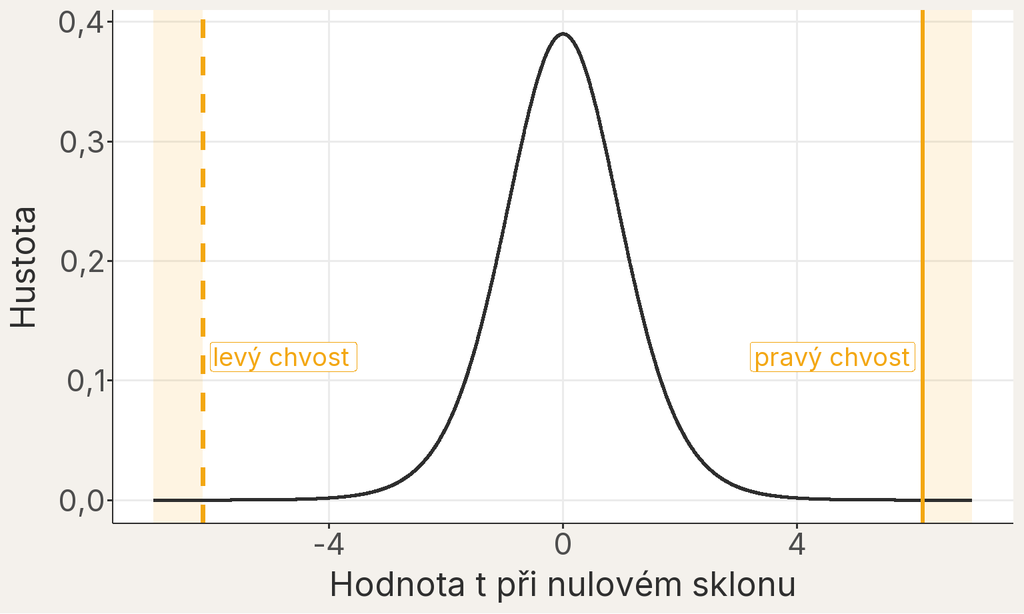

Oranžové pásy označují hodnoty t alespoň tak vzdálené od nuly jako pozorované t (plná čára) a jeho zrcadlový protějšek (čárkovaná čára). Hledaný podíl tvoří plocha pod křivkou uvnitř obou pásů. Je tak malá (asi 0,00007), že ji v obrázku téměř nevidíme, protože křivka v pásech leží prakticky na vodorovné ose.

**QuestionNajděte obě hledané plochy**

Na obrázku najděte:

1. pozorovanou kladnou t-statistiku;
2. stejně vzdálenou zápornou hodnotu;
3. všechny hodnoty alespoň tak extrémní vpravo;
4. všechny hodnoty alespoň tak extrémní vlevo.

Proč by vybarvení jen pravého chvostu neodpovídalo otázce, která připouští růst i pokles?

**DůležitéMožné odpovědi**

Pozorovaná t-statistika leží na plné oranžové čáře u $t\approx \text{6,16}$, stejně vzdálená záporná hodnota na čárkované čáře u $t\approx{-\text{6,16}}$. Hodnoty alespoň tak extrémní tvoří oba oranžové pásy: vše napravo od plné čáry a vše nalevo od čárkované. Plocha pod křivkou v pásech je ale tak malá, že ji téměř nevidíme. Jen pravý chvost by stačil, kdybychom se předem ptali pouze na růst. Naše alternativní hypotézaTvrzení, které připouští to, co nulová hypotéza vylučuje - typicky ‘efekt není nulový’ nebo ‘skupiny se liší’; značí se H_A. ale připouští i pokles, a stejně extrémní pokles by proti nulovému sklonu mluvil stejně silně.

Sečteme plochu v levém a pravém chvostu. V obrázku ji skoro nevidíme, protože tak daleko od nuly leží křivka téměř na vodorovné ose; plocha je **velmi malá, ale není nulová**. **Tomuto součtu se ve statistice říká p-hodnotaPravděpodobnost, že bychom při platnosti nulové hypotézy pozorovali data alespoň tak extrémní jako naše skutečná data..**

**PoznámkaP-hodnota v jedné větě**

Pokud by nulová hypotéza a předpoklady modelu platily, p-hodnota je pravděpodobnost, že získáme t-statistiku alespoň tak vzdálenou od nuly, jako je ta naše. Je to plocha pod referenční křivkou, a proto nabývá hodnot **od 0 do 1**.

Co z p-hodnoty můžeme přímo přečíst?

- **Vždy leží mezi 0 a 1.** Nula by znamenala žádnou plochu, jednička celou plochu pod křivkou.
- **Je podmíněná nulovým světem a modelem.** Nejde o pravděpodobnost, že je nulová hypotéza pravdivá.
- **U oboustranné otázky zahrnuje oba chvosty.** Počítáme kladné i záporné výsledky alespoň tak vzdálené od nuly.
- **Čím menší je p-hodnota, tím méně jsou data slučitelná s přesně nulovým sklonem.** Takto krajní výsledek by v nulovém světě vznikal méně často.

Pro krabí model je tento součet přibližně 0,000071. Kdyby byl skutečný sklon nulový a model správně popisoval vznik dat, takto krajní nebo ještě krajnější t-statistika by se objevila přibližně 7,1krát ze 100 000 opakování.

### 9.1 Tři studenti čtou stejný výsledek

**TipTři výklady stejné p-hodnoty**

**Anna:** „P-hodnota 0,000071 znamená, že pravděpodobnost nulové hypotézy je 0,000071.“

**Boris:** „Tak malá p-hodnota znamená, že biologický efektKvantitativní popis toho, jak se podle modelu mění odezva s prediktorem; zahrnuje směr, velikost a nejistotu odhadu, ale sám o sobě nedokládá příčinu. musí být obrovský.“

**Cyril:** „Kdyby byl skutečný sklon nulový a platil náš model, takto krajní výsledek by byl velmi vzácný.“

**QuestionKdo výsledek čte správně?**

Který student je nejblíže správné interpretaci? U zbývajících dvou přesně pojmenujte chybu. Co musí i správná věta přiznat o předpokladech modelu?

**DůležitéMožná odpověď**

Cyril jako jediný odpovídá na otázku, kterou p-hodnota skutečně klade. Anna zaměňuje pravděpodobnost dat za předpokladu nulové hypotézy za pravděpodobnost samotné hypotézy. Boris zaměňuje vzdálenost ve standardních chybách za biologickou velikost efektu; malá p-hodnota může vzniknout i u malého, velmi přesně odhadnutého sklonu. I Cyrilova věta platí jen tehdy, když přímka, chování residuí a nezávislost lokalit odpovídají skutečnosti.

**UpozorněníCo p-hodnota neříká**

Následující výklady jsou nesprávné. P-hodnota není:

- pravděpodobnost, že $H_0$ je pravdivá;
- pravděpodobnost, že alternativní hypotéza je pravdivá;
- velikost biologického efektu;
- pravděpodobnost, že výsledek vznikl „náhodou“;
- pravděpodobnost úspěšného zopakování studie;
- kontrola správnosti všech předpokladů;
- konečný verdikt o Bergmannově pravidle.

**TipDoplňující: jedna předem položená otázka a mnoho vyzkoušených otázek**

Naše p-hodnota odpovídá jedné předem pojmenované otázce o sklonu vůči zeměpisné šířce. Kdybychom však ze stejných dat bez předem daného plánu položili mnoho souvisejících otázek (tzv. **mnohonásobné testováníSituace, kdy provádíme mnoho testů najednou; s počtem testů roste šance, že alespoň jeden vyjde statisticky významně jen náhodou.**), zvýšila by se šance, že alespoň jedna analýza vytvoří nápadně malou p-hodnotu i bez přesvědčivého biologického signálu.

Proto k interpretaci patří také informace, kolik otázek výsledku předcházelo a zda byly zvoleny před pohledem na výsledky. Předem formulovaná biologická otázka omezuje hledání výsledku, který pouze vypadá zajímavě. V následující lekci uvidíme, jak se stejné riziko objeví, když z jedněch dat položíme několik souvisejících otázek.

## 10 Když musíme udělat rozhodnutí

P-hodnotaPravděpodobnost, že bychom při platnosti nulové hypotézy pozorovali data alespoň tak extrémní jako naše skutečná data. popisuje, nakolik jsou data slučitelná s nulovou hypotézouVýchozí předpoklad, který testujeme - typicky ‘efekt je nulový’ nebo ‘skupiny se neliší’; p-hodnota udává pravděpodobnost dat alespoň tak extrémních jako naše za předpokladu platnosti H₀.. V některých situacích ale musíme udělat také **rozhodnutí**: nulovou hypotézu zamítnout, nebo ji nezamítnout. K tomu potřebujeme pravidlo zvolené ještě před pohledem na výsledek.

Představme si mnoho studií, ve kterých nulová hypotéza opravdu platí. Jak často jsme ochotni připustit, že ji naše pravidlo přesto omylem zamítne? Hodnota 5 % například znamená, že při mnoha opakovaných studiích se stejným pravidlem připouštíme 5% dlouhodobé riziko falešného zamítnutí pravdivé nulové hypotézy.

Tato předem zvolená hranice se nazývá **hladina významnostiPředem zvolená hranice pro p-hodnotu (typicky α = 0,05); je to zároveň přijatelná pravděpodobnost chyby I. typu, tedy zamítnutí platné nulové hypotézy.** a označuje se řeckým písmenem $\alpha$ (alfa). Často se používá:

- 5 %, tedy $\alpha=\text{0,05}$;
- v přísněji nastavených analýzách například 1 %, tedy $\alpha=\text{0,01}$.

Ani 5 %, ani 1 % není přírodní zákon. Hranice má vycházet z pravidel oboru a z následků nesprávného rozhodnutí. Dva možné způsoby, jak se při takovém rozhodování splést, pojmenujeme v následující části.

### 10.1 Kritické hodnoty

Plochu pod t-křivkou ani její přesné hranice není snadné vypočítat ručně. Proto statistické učebnice před běžným používáním počítačů obsahovaly několik stran předem vypočtených tabulek. Z nich se vyhledávala **kritická hodnotaNásobitel standardní chyby použitý při konstrukci intervalu, nebo hranice testové statistiky v testu; závisí na hladině, stupních volnosti a zvoleném rozdělení.** pro zvolené rozděleníPopis toho, jaké hodnoty proměnná nabývá a jak často se vyskytují; může jít o pozorované rozdělení dat nebo o teoretické pravděpodobnostní rozdělení., hladinu významnosti a stupně volnostiPočet nezávislých informací dostupných pro odhad parametru; počet pozorování minus počet odhadovaných parametrů..

Tabulka tedy nepočítala přesnou plochu znovu pro každý model. Umožnila jednodušší postup: najít správnou hranici a porovnat s ní pozorovanou testovou statistiku. Pokud $|t|$ leželo za kritickou hodnotou, odpovídalo to p-hodnotě nejvýše $\alpha$ a nulová hypotéza se zamítla. Podrobnější tabulky také dovolovaly p-hodnotu zařadit mezi dvě uvedené hranice, ale obvykle nedaly tolik desetinných míst jako dnešní software.

Nebyla to jedna hranice pro všechny modely. Bylo potřeba zvolit:

- referenční rozdělení — zde t-rozděleníSouměrné rozdělení podobné normálnímu, ale s těžšími chvosty; jeho tvar určují stupně volnosti a používá se pro t-statistiku a intervaly spolehlivosti.;
- oboustrannou hladinu významnosti — zde $\alpha=\text{0,05}$;
- správný řádek podle stupňů volnosti — zde $df=11$.

Malá část takové tabulky by vypadala následovně. Hodnoty říkají, jak daleko od nuly začínají krajní 5 % t-rozdělení, rozdělená rovným dílem do obou chvostů.

| Residuální stupně volnosti | Kritická hodnota $\|t\|$ pro $\alpha=\text{0,05}$ |
| --- | --- |
| **11 (krabí model)** | **2,201** |
| 10 000 | 1,960 |

V řádku pro 11 stupňů volnosti najdeme hranice přibližně $-\text{2,201}$ a $+\text{2,201}$. Pozorované krabí $|t|=\text{6,16}$ leží daleko za nimi.

Teď stejné hranice přidáme přímo do známého t-rozdělení. Fialová vyznačuje předem zvolené kritické oblasti; oranžová ukazuje výsledek našeho modelu.

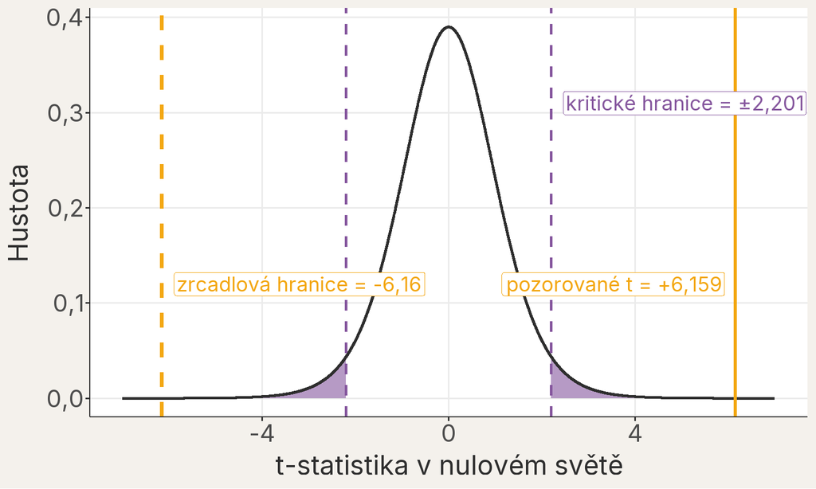

Kritické hranice a pozorovaná t-statistika v nulovém t-rozdělení. Fialové chvosty mají dohromady plochu alfa; oranžové hranice vymezují oboustrannou p-hodnotu.

Fialové chvosty za kritickými hranicemi mají dohromady plochu $\alpha=\text{0,05}$. Skutečně pozorovaná t-statistikaTestová statistika: rozdíl odhadu od hodnoty v nulové hypotéze (obvykle 0) vydělený standardní chybou; říká, o kolik standardních chyb je odhad od nuly. je kladná; záporná oranžová hranice je pouze její zrcadlový protějšek pro oboustrannou otázku. P-hodnota je plocha pod t-křivkou za oběma oranžovými hranicemi. Protože $|t|=\text{6,16}$ leží za kritickou hodnotou 2,201, vedou porovnání $|t|$ s kritickou hodnotou a porovnání p-hodnoty s $\alpha$ ke stejnému rozhodnutí.

Při běžné analýze se o ruční vyhledávání kritických hodnot ani o výpočet ploch pod křivkou nemusíme starat. Test každého koeficientu za nás spočítá funkce `summary()`. Podívejme se znovu na známý výpis:

```r
# Znovu zobrazíme celý souhrn stejného modelu.
summary(object = mod_krabi)
```

```
Call:
lm(formula = prumerna_sirka_mm ~ zemepisna_sirka, data = data_lokality)

Residuals:
     Min       1Q   Median       3Q      Max
-1.77895 -0.74796  0.05101  0.73779  1.87228

Coefficients:
                Estimate Std. Error t value Pr(>|t|)
(Intercept)     -3.74716    3.00884  -1.245    0.239
zemepisna_sirka  0.48953    0.07948   6.159 7.11e-05 ***
---
Signif. codes:  0 '***' 0.001 '**' 0.01 '*' 0.05 '.' 0.1 ' ' 1

Residual standard error: 1.226 on 11 degrees of freedom
Multiple R-squared:  0.7752,    Adjusted R-squared:  0.7548
F-statistic: 37.94 on 1 and 11 DF,  p-value: 7.112e-05
```

P-hodnotu pro naši biologickou otázku najdeme v tabulce `Coefficients`:

- vybereme řádek `zemepisna_sirka`, protože právě ten obsahuje sklonParametr lineárního modelu udávající, o kolik se v průměru liší odezva dvou pozorování, jejichž prediktor se liší o jednu jednotku (při stejných hodnotách ostatních prediktorů). vztahu k zeměpisné šířce;
- ve sloupci `t value` vidíme pozorovanou t-statistiku 6,159;
- ve sloupci `Pr(>|t|)` vidíme oboustrannou p-hodnotu 0,000071; R ji vypíše ve vědeckém zápisu 7.11e-05, kde `e-05` znamená posunutí desetinné tečky o pět míst doleva;
- počet residuálních stupňů volnosti 11 najdeme níže ve výpisu na řádku `Residual standard error` (residuální směrodatná odchylkaOdhad typické velikosti residuí v jednotkách odezvy; popisuje rozptýlení pozorování kolem hodnot odhadnutých modelem.).

P-hodnotu budeme při běžné práci číst právě z tohoto sloupce. Tabulka kritických hodnot, porovnání s $|t|$ a porovnání p-hodnoty s $\alpha$ jsou jen tři zápisy stejného rozhodovacího pravidla. Počítač princip porovnání nezměnil; stejné hranice a plochy však vypočítá za nás.

**TipDoplňující: kritická hodnota a p-hodnota pomocí qt() a pt()**

Kdo chce vidět, jak R hranice a plochy počítá, může použít funkce `qt()` a `pt()`. Při běžné práci je nepotřebujeme.

Funkce `qt()` vyhledá kritickou hodnotu. Je to tatáž kritická hodnota $t_{1-\alpha/2,\,n-2}$, kterou jsme v předchozí lekci násobili standardní chybuMíra přesnosti odhadu parametru (průměru, sklonu…); odhaduje z jediného výběru, jak moc by se odhady typicky lišily mezi opakovanými výběry stejné velikosti. při stavbě 95% intervalu spolehlivostiRozsah hodnot vypočtený z dat postupem, který při opakovaných výběrech pokryje skutečnou hodnotu parametru ve zvoleném podílu případů (typicky 95 %). sklonu. Argument `p = 1 - 0.05 / 2`, tedy 0,975, žádá hranici, pod kterou leží 97,5 % plochy t-křivky. Nad ní tak zbývá 2,5 % v pravém chvostu a zrcadlově stejně tolik v levém, dohromady $\alpha$. Funkce `pt()` pak spočítá plochu za pozorovaným t, tedy p-hodnotu. Následující kód používá přímo model, který jsme už fitovali:

```r
# Hranici spočítáme pro alfa = 0,05 a df našeho modelu. Alfu dělíme dvěma,
#   protože ji rozdělujeme rovným dílem do obou chvostů; 1 - 0.05 / 2 je
#   tedy hranice, pod kterou leží 97,5 % plochy.
kriticke_t <-
  qt(
    p = 1 - 0.05 / 2,
    df = df.residual(object = mod_krabi)
  )

# t-statistiku přečteme z tabulky koeficientů modelu.
tabulka_koeficientu <- coef(object = summary(object = mod_krabi))
t_krabi <- tabulka_koeficientu["zemepisna_sirka", "t value"]

# Obě krajní plochy t-rozdělení sečteme.
p_krabi <-
  2 * pt(
    q = -abs(x = t_krabi),
    df = df.residual(object = mod_krabi)
  )

c(
  kriticka_hodnota = kriticke_t,
  t_krabi = t_krabi,
  p_hodnota = p_krabi
)
```

```
kriticka_hodnota          t_krabi        p_hodnota
    2.200985e+00     6.159372e+00     7.112446e-05
```

```r
abs(x = t_krabi) >= kriticke_t
```

```
[1] TRUE
```

První výpis obsahuje tři čísla: kritickou hodnotu přibližně 2,201, krabí t-statistiku přibližně 6,16 a p-hodnotu přibližně 0,000071. Protože je p-hodnota velmi malá, R vypsal všechna tři čísla ve vědeckém zápisu: `e+00` znamená „krát 10 na nultou“, tedy číslo beze změny, a `e-05` znamená posunutí desetinné tečky o pět míst doleva. Poslední řádek `TRUE` odpovídá na otázku, zda $|t|$ leží alespoň tak daleko od nuly jako kritická hodnota. Odpověď „ano“ znamená, že nulovou hypotézu při $\alpha=\text{0,05}$ zamítáme.

**TipDoplňující: proč se mluví o t-testu**

Test, který R provedl pro sklon, patří mezi takzvané **t-testyTest založený na t-statistice (odhad dělený standardní chybou); nejčastěji porovnává průměry dvou skupin nebo testuje, zda je koeficient modelu nulový.**: odhadČíslo vypočtené z pozorovaných dat jako přiblížení neznámé vlastnosti nebo parametru; jiný srovnatelný výběr může dát jiný odhad. vydělíme jeho standardní chybou a výslednou t-statistiku porovnáme s t-rozdělením. V učebnicích a článcích se pod názvem t-test nejčastěji objevuje porovnání průměrů dvou skupin, například kontroly a zásahu. K tomuto t-testu se můžeme vrátit později v kurzu. Uvidíme, že jde o stejný lineární modelStatistický model, v němž je průměrná odezva součtem interceptu a prediktorů násobených koeficienty; lineární je v koeficientech, takže nemusí jít jen o přímku., jen s prediktoremProměnná, pomocí níž vysvětlujeme variabilitu odezvy; v notaci y ~ x je prediktor x., který označuje příslušnost ke skupině.

Rozhodovací pravidlo pak zní:

| Výsledek porovnání | Běžné rozhodnutí a označení |
| --- | --- |
| p-hodnota je nejvýše $\alpha$ | **zamítneme nulovou hypotézu**; výsledek označíme jako **statisticky významný** |
| p-hodnota je větší než $\alpha$ | **nulovou hypotézu nezamítneme**; výsledek není na zvolené hladině statisticky významný |

V těchto materiálech používáme český termín **statisticky významnýOznačení výsledku, jehož p-hodnota je nejvýše zvolená hladina významnosti α; neříká nic o tom, zda je efekt velký nebo biologicky důležitý.**. V článcích často uvidíte také synonymum *statisticky signifikantní* (anglicky *statistically significant*). V obou případech jde o totéž pravidlo: p-hodnota je nejvýše rovna předem zvolené hranici, tedy $p\leq\alpha$.

**UpozorněníStatisticky významný neznamená biologicky důležitý**

Slovo „významný“ zde **neříká**, že je efektKvantitativní popis toho, jak se podle modelu mění odezva s prediktorem; zahrnuje směr, velikost a nejistotu odhadu, ale sám o sobě nedokládá příčinu. velký, biologicky důležitý nebo určitě pravdivý. O biologickém významu rozhodujeme podle velikosti efektu v jeho jednotkách a podle biologického kontextu, nikoli podle samotného porovnání p-hodnoty s hranicí.

U krabů je p-hodnota 0,000071. Při $\alpha=\text{0,05}$ proto nulovou hypotézu o přesně nulovém sklonu zamítáme a výsledek nazveme statisticky významným. Odpovídající 95% interval spolehlivosti nulu neprotíná a vede ke stejnému rozhodnutí; proč tomu tak je, ukáže následující část. Neříkáme tím, že jsme alternativní hypotézuTvrzení, které připouští to, co nulová hypotéza vylučuje - typicky ‘efekt není nulový’ nebo ‘skupiny se liší’; značí se H_A. dokázali; říkáme, že přesně nulový sklon je za předpokladů modelu s výsledkem velmi obtížně slučitelný.

### 10.2 Stejnou otázku můžeme položit intervalu

Teď už víme, proč porovnáváme právě 95% interval s hladinou $\alpha=\text{0,05}$. U oboustranného testu patří k sobě:

- kritické hranice vymezující prostředních 95 % příslušného referenčního rozdělení;
- 95% interval spolehlivosti vytvořený pomocí stejných hranic;
- zbývajících 5 % rozdělených mezi oba chvosty;
- rozhodovací hranice $\alpha=\text{0,05}$.

Stejnou otázku proto můžeme položit bez dalšího výpočtu p-hodnoty: **obsahuje 95% interval spolehlivosti nulový sklon?**

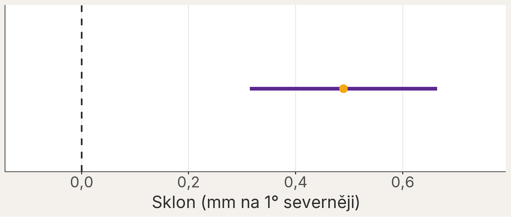

Odhad sklonu a jeho 95% interval spolehlivosti. Svislá čára označuje nulový sklon, tedy žádnou lineární změnu k severu.

Krabí interval od 0,315 do 0,664 mm na stupeň nulu neprotíná. Při oboustranné hladině $\alpha=\text{0,05}$ proto vede ke stejnému rozhodnutí jako p-hodnota: nulový sklon zamítneme. Kdyby 95% interval nulu protínal, p-hodnota by při stejném modelu byla větší než $\alpha=\text{0,05}$ a nulovou hypotézu bychom nezamítli.

Interval nám přitom ukazuje víc než samotné rozhodnutí. Vidíme z něj také rozsah kladných velikostí vztahu, které zůstávají slučitelné s daty a modelem.

**Nezamítnout nulovou hypotézu naopak neznamená dokázat, že efekt je přesně nula.**

**TipDoplňující: nula nemusí být biologicky nejdůležitější hranice**

Nulový sklon je matematicky jednoduchá referenční hodnota, ale biologická otázka může mít důležitější hranici. Výzkumníci mohou například předem určit, jak velký kladný sklon šířky krunýře na jeden stupeň je ještě biologicky zanedbatelný a od jaké velikosti už by měnil jejich biologický závěr. Konkrétní hranice musí vycházet z biologických znalostí a měla by být zdůvodněna před čtením výsledku.

Interval spolehlivosti můžeme porovnat nejen s nulou, ale také s takovou předem zvolenou hranicí. Může například celý ležet pod hranicí biologicky důležitého kladného sklonu, i když obsahuje nulu; v takovém případě mezi hodnotami slučitelnými s daty a modelem není velký kladný efekt, ale interval neříká automaticky totéž o opačném směru. Jindy může interval připouštět nulový i biologicky významný kladný efekt. Formální testy ekvivalence patří do pokročilejšího kurzu; zde stačí číst celý rozsah efektů slučitelných s daty.

## 11 Dva způsoby, jak se splést

Rozhodovací pravidlo už máme: p-hodnotuPravděpodobnost, že bychom při platnosti nulové hypotézy pozorovali data alespoň tak extrémní jako naše skutečná data. porovnáme s předem zvolenou hladinou významnostiPředem zvolená hranice pro p-hodnotu (typicky α = 0,05); je to zároveň přijatelná pravděpodobnost chyby I. typu, tedy zamítnutí platné nulové hypotézy.. Rozhodnutí ale není totéž co jistota. Může odpovídat skutečnosti, nebo se můžeme splést dvěma různými způsoby.

### 11.1 Rychlá paměťová pomůcka

U těhotenského testu si představme nulový stav „těhotenství není přítomno“:

- **chyba I. typuZamítnutí nulové hypotézy, která ve skutečnosti platí; její pravděpodobnost je rovna zvolené hladině významnosti α. neboli falešně pozitivní výsledek:** test hlásí těhotenství v očividně nemožné situaci;
- **chyba II. typuNezamítnutí nulové hypotézy, která ve skutečnosti neplatí - test skutečný efekt nezachytí; její pravděpodobnost se značí β. neboli falešně negativní výsledek:** test nehlásí těhotenství v očividně pokročilé fázi.

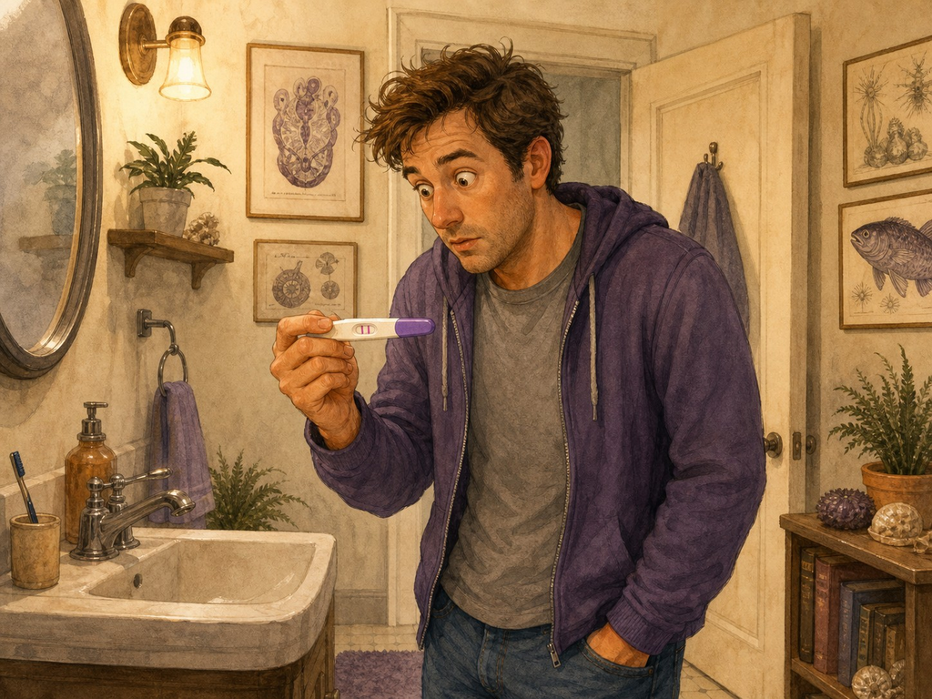

Falešně pozitivní výsledek: zjevně netěhotný muž překvapeně drží pozitivní těhotenský test.

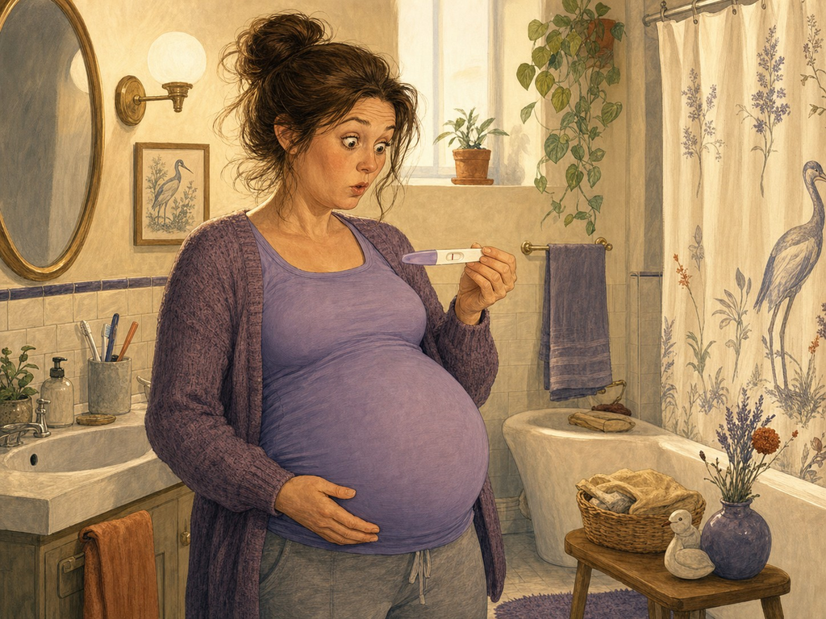

Falešně negativní výsledek: zjevně těhotná žena překvapeně drží negativní těhotenský test.

Obrázek 1: Dvě úmyslně absurdní situace jako paměťová pomůcka: vlevo chyba I. typu, vpravo chyba II. typu. Ilustrace vytvořená pomocí AI.

Je to úmyslně absurdní zkratka. Skutečná definice vždy závisí na tom, jak jsme určili nulový stav.

- **Chyba I. typu:** zamítneme nulovou hypotézuVýchozí předpoklad, který testujeme - typicky ‘efekt je nulový’ nebo ‘skupiny se neliší’; p-hodnota udává pravděpodobnost dat alespoň tak extrémních jako naše za předpokladu platnosti H₀., přestože je pravdivá. Jde o falešně pozitivní závěr neboli falešný poplach. Předem zvolená hladina významnosti $\alpha$ určuje dlouhodobé riziko právě této chyby.
- **Chyba II. typu:** nulovou hypotézu nezamítneme, přestože ve skutečnosti neplatí a existuje skutečný efektKvantitativní popis toho, jak se podle modelu mění odezva s prediktorem; zahrnuje směr, velikost a nejistotu odhadu, ale sám o sobě nedokládá příčinu..

### 11.2 Biologický příklad: invazní druh

Představme si průzkum, jehož nulová hypotéza zní:

$$H_0:\ \text{invazní druh v oblasti není přítomen}.$$

| Skutečnost | Průzkum hlásí „nepřítomen“ | Průzkum hlásí „přítomen“ |
| --- | --- | --- |
| Druh není přítomen | správné rozhodnutí | **chyba I. typu:** zbytečný zásah |
| Druh je přítomen | **chyba II. typu:** přehlédnutá invaze | správné rozhodnutí |

**QuestionRozhodněte — Která chyba je horší?**

1. Zařaďte oba těhotenské příklady jako chybu I. nebo II. typu.
2. Totéž udělejte pro invazní druh.
3. Která chyba může být v ochraně přírody závažnější?
4. Jak odpověď závisí na ceně zásahu, rychlosti šíření a vratnosti škod?

**DůležitéMožné odpovědi**

Pozitivní test u muže je chyba I. typu, negativní test v pokročilém těhotenství chyba II. typu. U invazního druhu je zbytečný zásah chybou I. typu a přehlédnutá invaze chybou II. typu. Přehlédnutá invaze bývá závažnější, když se druh rychle šíří a škody jsou nevratné; levný a vratný zásah naopak snese více falešných poplachů.

Žádný typ chyby není vždy horší. Záleží na následcích.

U krabího modelu by chyba I. typu znamenala, že tvrdíme vztah, přestože je populační sklonParametr lineárního modelu udávající, o kolik se v průměru liší odezva dvou pozorování, jejichž prediktor se liší o jednu jednotku (při stejných hodnotách ostatních prediktorů). nulový. Chyba II. typu by znamenala, že skutečný vztah neodhalíme. Tato chyba hrozí hlavně v malých nebo velmi variabilních studiích, kde je standardní chybaMíra přesnosti odhadu parametru (průměru, sklonu…); odhaduje z jediného výběru, jak moc by se odhady typicky lišily mezi opakovanými výběry stejné velikosti. sklonu velká. Proto **nezamítnutí nulové hypotézy není důkazem nulového efektu**.

## 12 Co tedy můžeme říct o krabech?

Vraťme se k původní otázce.

**Dokázali jsme, že severněji žijící krabi jsou větší?**

Ne. Máme silný a dobře popsaný výsledek pro 13 sledovaných slanisek a jednoduchý model. To není totéž jako definitivní důkaz obecného biologického pravidla.

**QuestionKterá výsledková věta vám řekne více?**

Porovnejte dva závěry:

> **A:** „$p<\text{0,05}$, proto jsou severní krabi větší.“

> **B:** „OdhadČíslo vypočtené z pozorovaných dat jako přiblížení neznámé vlastnosti nebo parametru; jiný srovnatelný výběr může dát jiný odhad. sklonuParametr lineárního modelu udávající, o kolik se v průměru liší odezva dvou pozorování, jejichž prediktor se liší o jednu jednotku (při stejných hodnotách ostatních prediktorů). říká, že průměrná šířka krunýřeSoučet hodnot vydělený jejich počtem; nejběžnější míra polohy (střední hodnoty). rostla přibližně o 0,490 mm na stupeň; intervalRozsah hodnot vypočtený z dat postupem, který při opakovaných výběrech pokryje skutečnou hodnotu parametru ve zvoleném podílu případů (typicky 95 %). od 0,315 do 0,664 mm ukazuje, jak velký vztah je s daty slučitelný.“

Která věta vám o krabech řekne více? Co je špatně ve větě A? Co ještě chybí i ve větě B?

**DůležitéMožná odpověď**

Více řekne věta B: obsahuje velikost vztahu v jednotkách i jeho nejistotuRozsah, v němž nevíme přesnou hodnotu parametru kvůli omezenému výběru a výběrové variabilitě; kvantifikuje se pomocí standardních chyb a intervalů spolehlivosti.. Věta A zaměňuje statistickou významnostOznačení výsledku, jehož p-hodnota je nejvýše zvolená hladina významnosti α; neříká nic o tom, zda je efekt velký nebo biologicky důležitý. za důkaz a vůbec neříká, o kolik jsou krabi větší. Větě B ještě chybí biologický význam změny, srovnání s nulovým sklonem a omezení studie.

Úplný závěr můžeme poskládat z následujících odpovědí:

| Otázka | Odpověď v krabím příběhu |
| --- | --- |
| Jak velký je vztah? | 0,490 mm na 1°; 2,45 mm na 5° |
| Je biologicky zajímavý? | Přes sledovaný rozsah odpovídá asi 6,22 mm |
| Jak přesný je odhad? | 95% CI [0,315; 0,664] mm na 1° |
| Jak dobře se data shodují s nulovým sklonem? | $t\approx \text{6,16}$, $df=11$, $p<\text{0,001}$ |
| Jaké je rozhodnutí při $\alpha=\text{0,05}$? | výsledek je statisticky významný; nulovou hypotézuVýchozí předpoklad, který testujeme - typicky ‘efekt je nulový’ nebo ‘skupiny se neliší’; p-hodnota udává pravděpodobnost dat alespoň tak extrémních j… |
| Co ještě může závěr omezovat? | výběrSoubor pozorování, z něhož počítáme statistiky a pomocí něhož se snažíme popsat širší populaci nebo proces. lokalit, blízká slaniska nemusí být nezávislá, zprůměrování krabů a jednoduchost modelu |

**QuestionVaše verze — Vysvětlete výsledek biologovi**

Napište pět až šest vět tak, aby čtenář nejprve pochopil, **co se s velikostí krabů mění a o kolik**. Potom přidejte nejistotu, srovnání s nulovým sklonem a nakonec omezení toho, co lze z těchto slanisek zobecnit.

**DůležitéMožná odpověď: příklad úplného výsledku**

Na 13 sledovaných slaniskách atlantského pobřeží se průměrná šířka krunýře samců zvyšovala přibližně o 0,490 mm na každý stupeň zeměpisné šířky, tedy asi o 2,45 mm na 5°. Přes celý sledovaný rozsah odpovídá odhadnutá přímka změně přibližně 6,22 mm, která je vzhledem k velikosti krabů biologicky zajímavá. 95% interval spolehlivosti sahal od 0,315 do 0,664 mm na stupeň. Při hladině významnostiPředem zvolená hranice pro p-hodnotu (typicky α = 0,05); je to zároveň přijatelná pravděpodobnost chyby I. typu, tedy zamítnutí platné nulové hypotézy. $\alpha=\text{0,05}$ byl výsledek statisticky významnýOznačení výsledku, jehož p-hodnota je nejvýše zvolená hladina významnosti α; neříká nic o tom, zda je efekt velký nebo biologicky důležitý.; při předpokladech jednoduchého lineárního modeluStatistický model, v němž je průměrná odezva součtem interceptu a prediktorů násobených koeficienty; lineární je v koeficientech, takže nemusí jít jen o přímku. byla data obtížně slučitelná s přesně nulovým sklonem ($t\approx \text{6,16}$, $df=11$, $p<\text{0,001}$). Výsledek podporuje kladný vztah mezi zeměpisnou šířkou a průměrnou velikostí samců na sledovaných slaniskách, ale sám neprokazuje, že zeměpisná šířka velikost krabů způsobuje.

### 12.1 Co se do jedné přímky nevešlo

Diagnostické grafySoubor grafických a numerických kontrol ověřujících, zda jsou rozumně splněny předpoklady modelu: linearita, nezávislost pozorování, konstantní rozptyl a normalita residuí, a zda závěr nestojí na několika vlivných pozorováních. jsme prohlédli hned po fitování modelu. Ani dobrý diagnostický obraz ale neřeší všechna omezení studie a zvoleného modelu:

- **Jsou všechna slaniska stejně dobře změřena?** Ne úplně. Počty krabů se mírně liší, takže průměry nemají stejnou přesnost. Náš jednoduchý model přesto bere každý průměr stejně vážně.
- **Co se stalo s rozdíly mezi jednotlivými kraby?** Zprůměrováním jsme je z hlavní analýzy odstranili. Pro naši otázku to bylo užitečné, ale část informace jsme ztratili.
- **Nestojí přímka hlavně na několika lokalitách?** Cookova vzdálenostMíra vlivu jednoho pozorování na model: vyjadřuje, jak moc by se změnily odhadnuté hodnoty, kdybychom toto pozorování vynechali. upozornila na lokality GTM a SI. Když postupně vynecháme vždy jednu lokalitu, zůstávají všechny sklony kladné a leží přibližně mezi 0,429 a 0,559 mm na stupeň. Směr vztahu tedy nestojí na jediné lokalitě; jak velký sklon vyjde, ale na výběru lokalit do určité míry závisí.
- **Mohou si blízká slaniska být podobnější?** Ano. Geografické lokality nemusí být zcela nezávislé a přímka není úplný prostorový ekologický model.
- **Dokazuje vztah příčinu?** Ne. Studie je observační. Zeměpisná šířka může souviset s teplotou, délkou sezóny i dalšími podmínkami.

Kvůli těmto omezením nemusíme výsledek zahodit. Musíme ale být opatrní, když ho zobecňujeme na jiná místa, populaceCelá množina jednotek nebo širší proces, o kterém chceme pomocí výběru něco zjistit; její vlastnosti (parametry) obvykle neznáme. nebo biologické mechanismy.

## 13 Měsíc pořád není ze sýra

P-hodnotaPravděpodobnost, že bychom při platnosti nulové hypotézy pozorovali data alespoň tak extrémní jako naše skutečná data. nám neřekne pravděpodobnost, že je Měsíc ze sýra. Stejně tak nám neřekne pravděpodobnost, že je Bergmannovo pravidlo pravdivé.

Odpovídá na mnohem užší otázku: **Jak neobvyklá by byla naše testová statistikaČíslo vypočtené z dat, které porovnáváme s referenčním rozdělením platným při nulové hypotéze; z tohoto porovnání získáme p-hodnotu., kdyby platilo přesně zvolené nulové tvrzení a předpoklady modelu?**

Vědecký závěr vzniká spojením více částí:

- velikosti efektuKvantitativní popis toho, jak se podle modelu mění odezva s prediktorem; zahrnuje směr, velikost a nejistotu odhadu, ale sám o sobě nedokládá příčinu.;
- biologického významu;
- nejistotyRozsah, v němž nevíme přesnou hodnotu parametru kvůli omezenému výběru a výběrové variabilitě; kvantifikuje se pomocí standardních chyb a intervalů spolehlivosti.;
- slučitelnosti s konkrétním nulovým tvrzením;
- uspořádání studie;
- předpokladů a možných chyb;
- dosavadních znalostí a dalších studií.

**PoznámkaHlavní myšlenka lekce**

**Věda nezískává pravdu z $p<\text{0,05}$. Staví opatrné a opravitelné závěry z efektu, nejistoty, kvality studie a souvislostí.**

## 14 Co bude následovat dál

Zeměpisná šířka byla numerickýProměnná, jejíž hodnoty jsou čísla se smysluplnou velikostí nebo rozdílem; může být diskrétní, například počet, nebo spojitá, například délka. prediktorProměnná, pomocí níž vysvětlujeme variabilitu odezvy; v notaci y ~ x je prediktor x., a proto jsme vztah popisovali sklonemParametr lineárního modelu udávající, o kolik se v průměru liší odezva dvou pozorování, jejichž prediktor se liší o jednu jednotku (při stejných hodnotách ostatních prediktorů).. V následující lekci nebude prediktorem číslo, ale příslušnost ke skupině, například kontrola a zásah. Místo sklonu se budeme ptát na rozdíl mezi dvěma průměrySoučet hodnot vydělený jejich počtem; nejběžnější míra polohy (střední hodnoty)..

Způsob uvažování zůstane stejný: nejprve velikost rozdílu a jeho nejistotaRozsah, v němž nevíme přesnou hodnotu parametru kvůli omezenému výběru a výběrové variabilitě; kvantifikuje se pomocí standardních chyb a intervalů spolehlivosti., potom biologický význam, srovnání s přesnou nulou a nakonec omezení studie.

## 15 Shrnutí

- Testovatelnost tvrzení není totéž jako jeho věrohodnost.
- Nulový sklonParametr lineárního modelu udávající, o kolik se v průměru liší odezva dvou pozorování, jejichž prediktor se liší o jednu jednotku (při stejných hodnotách ostatních prediktorů). znamená žádný **systematický lineární trend**, nikoli žádnou náhodnou variabilituObecný termín pro rozsah, v němž se hodnoty proměnné liší od sebe navzájem; kvantifikuje se pomocí rozptylu, SD, IQR nebo rozsahu. mezi lokalitami.
- T-statistikaTestová statistika: rozdíl odhadu od hodnoty v nulové hypotéze (obvykle 0) vydělený standardní chybou; říká, o kolik standardních chyb je odhad od nuly. měří vzdálenost od nulového sklonu ve standardních chybáchMíra přesnosti odhadu parametru (průměru, sklonu…); odhaduje z jediného výběru, jak moc by se odhady typicky lišily mezi opakovanými výběry stejné velikosti..
- Stupně volnostiPočet nezávislých informací dostupných pro odhad parametru; počet pozorování minus počet odhadovaných parametrů. určují, kterou referenční t-křivku použijeme a kolik plochy zůstává daleko od nuly.
- P-hodnotaPravděpodobnost, že bychom při platnosti nulové hypotézy pozorovali data alespoň tak extrémní jako naše skutečná data. je podmíněná plocha v chvostech referenčního rozděleníPopis toho, jaké hodnoty proměnná nabývá a jak často se vyskytují; může jít o pozorované rozdělení dat nebo o teoretické pravděpodobnostní rozdělení., nikoli pravděpodobnost pravdivosti hypotézy.
- „Statisticky významnýOznačení výsledku, jehož p-hodnota je nejvýše zvolená hladina významnosti α; neříká nic o tom, zda je efekt velký nebo biologicky důležitý.“ je výsledek rozhodovacího pravidla; neznamená automaticky velký nebo biologicky důležitý efektKvantitativní popis toho, jak se podle modelu mění odezva s prediktorem; zahrnuje směr, velikost a nejistotu odhadu, ale sám o sobě nedokládá příčinu..
- Zamítnutí i nezamítnutí nulové hypotézyVýchozí předpoklad, který testujeme - typicky ‘efekt je nulový’ nebo ‘skupiny se neliší’; p-hodnota udává pravděpodobnost dat alespoň tak extrémních jako naše za předpokladu platnosti H₀. může být chybné a závažnost obou chyb závisí na jejich důsledcích.
- Dobrá vědecká odpověď spojuje velikost vztahu, nejistotuRozsah, v němž nevíme přesnou hodnotu parametru kvůli omezenému výběru a výběrové variabilitě; kvantifikuje se pomocí standardních chyb a intervalů spolehlivosti., srovnání s přesnou nulou, diagnostiku modeluSoubor grafických a numerických kontrol ověřujících, zda jsou rozumně splněny předpoklady modelu: linearita, nezávislost pozorování, konstantní rozptyl a normalita residuí, a zda závěr nestojí na několika vlivných pozorováních. a omezení studie.

### 15.1 Závěrečná otázka

Kolega vám ukáže jen titulek „p < 0,05: severní krabi jsou větší“. Jaké tři otázky mu položíte, než titulku uvěříte?

**DůležitéMožné otázky**

O kolik milimetrů na stupeň se krabi liší a je to biologicky hodně? Jak široký je interval spolehlivostiRozsah hodnot vypočtený z dat postupem, který při opakovaných výběrech pokryje skutečnou hodnotu parametru ve zvoleném podílu případů (typicky 95 %).? Kolik slanisek studie měla a jak byla vybrána? Sedí přímka k datům a jsou slaniska nezávislá? A tvrdí titulek jen souvislost, nebo i příčinu?

## Slovníček pojmů

Pojmy použité v těchto materiálech a jejich definice. Úplný průběžně aktualizovaný slovníček je dostupný také [online](https://cuni-natur-biostatistics.github.io/slovnik/).

| term | definition |
| --- | --- |
| alternativni-hypoteza | Tvrzení, které připouští to, co nulová hypotéza vylučuje - typicky 'efekt není nulový' nebo 'skupiny se liší'; značí se H_A. |
| chyba-i-typu | Zamítnutí nulové hypotézy, která ve skutečnosti platí; její pravděpodobnost je rovna zvolené hladině významnosti α. |
| chyba-ii-typu | Nezamítnutí nulové hypotézy, která ve skutečnosti neplatí - test skutečný efekt nezachytí; její pravděpodobnost se značí β. |
| cookova-vzdalenost | Míra vlivu jednoho pozorování na model: vyjadřuje, jak moc by se změnily odhadnuté hodnoty, kdybychom toto pozorování vynechali. |
| diagnostika-modelu | Soubor grafických a numerických kontrol ověřujících, zda jsou rozumně splněny předpoklady modelu: linearita, nezávislost pozorování, konstantní rozptyl a normalita residuí, a zda závěr nestojí na něko… |
| efekt | Kvantitativní popis toho, jak se podle modelu mění odezva s prediktorem; zahrnuje směr, velikost a nejistotu odhadu, ale sám o sobě nedokládá příčinu. |
| hierarchicka-data | Data, kde pozorování nejsou zcela nezávislá - jsou seskupena do vyšší úrovně (lokality, bloky, jedinci s opakovanými měřeními). |
| histogram | Graf zobrazující rozdělení hodnot numerické proměnné: hodnoty jsou rozděleny do sousedních intervalů (košů), výška sloupce udává četnost v daném koši. |
| hladina-vyznamnosti | Předem zvolená hranice pro p-hodnotu (typicky α = 0,05); je to zároveň přijatelná pravděpodobnost chyby I. typu, tedy zamítnutí platné nulové hypotézy. |
| intercept | Parametr modelu: odhadnutá hodnota odezvy, když jsou všechny numerické prediktory rovny nule a kategoriální prediktory jsou v referenční skupině; geometricky jde o úsek na ose y. |
| interval-spolehlivosti | Rozsah hodnot vypočtený z dat postupem, který při opakovaných výběrech pokryje skutečnou hodnotu parametru ve zvoleném podílu případů (typicky 95 %). |
| jednotka-pozorovani | Entita nebo děj, o kterém jedno pozorování nese informace, například jedinec, plocha, vzorek vody nebo jedna erupce. |
| kriticka-hodnota | Násobitel standardní chyby použitý při konstrukci intervalu, nebo hranice testové statistiky v testu; závisí na hladině, stupních volnosti a zvoleném rozdělení. |
| linearni-model | Statistický model, v němž je průměrná odezva součtem interceptu a prediktorů násobených koeficienty; lineární je v koeficientech, takže nemusí jít jen o přímku. |
| mnohonasobne-testovani | Situace, kdy provádíme mnoho testů najednou; s počtem testů roste šance, že alespoň jeden vyjde statisticky významně jen náhodou. |
| nahodny-vyber | Výběr, v němž má každá jednotka populace známou (typicky stejnou) šanci být vybrána; jen u takového výběru lze výsledky zobecnit bez dalších předpokladů. |
| nejistota | Rozsah, v němž nevíme přesnou hodnotu parametru kvůli omezenému výběru a výběrové variabilitě; kvantifikuje se pomocí standardních chyb a intervalů spolehlivosti. |
| nulova-hypoteza | Výchozí předpoklad, který testujeme - typicky 'efekt je nulový' nebo 'skupiny se neliší'; p-hodnota udává pravděpodobnost dat alespoň tak extrémních jako naše za předpokladu platnosti H₀. |
| numericka-promenna | Proměnná, jejíž hodnoty jsou čísla se smysluplnou velikostí nebo rozdílem; může být diskrétní, například počet, nebo spojitá, například délka. |
| odezva | Proměnná, jejíž variabilitu se snažíme vysvětlit nebo předpovědět; v notaci modelu `y ~ x` je odezva `y`. |
| odhad | Číslo vypočtené z pozorovaných dat jako přiblížení neznámé vlastnosti nebo parametru; jiný srovnatelný výběr může dát jiný odhad. |
| odhadnuta-hodnota | Hodnota odezvy, kterou fitovaný model přiřadí pozorování na základě jeho hodnot prediktorů; značí se často ŷ. |
| p-hodnota | Pravděpodobnost, že bychom při platnosti nulové hypotézy pozorovali data alespoň tak extrémní jako naše skutečná data. |
| pakovy-efekt | Míra toho, jak neobvyklé hodnoty prediktorů má jedno pozorování ve srovnání s ostatními; nezávisí na naměřené odezvě. |
| parametry-modelu | Číselné hodnoty odhadnuté z dat definující tvar modelu; v lineárním modelu jsou to intercept a sklon(y). |
| pas-spolehlivosti | Pás kolem odhadnuté přímky, který pro každou hodnotu prediktoru ukazuje interval spolehlivosti pro průměrnou hodnotu odezvy; neukazuje, kde leží 95 % pozorování. |
| populace | Celá množina jednotek nebo širší proces, o kterém chceme pomocí výběru něco zjistit; její vlastnosti (parametry) obvykle neznáme. |
| pozorovani | Jeden zaznamenaný případ v datech, který obsahuje hodnoty jedné nebo více proměnných. |
| prediktor | Proměnná, pomocí níž vysvětlujeme variabilitu odezvy; v notaci `y ~ x` je prediktor `x`. |
| prumer | Součet hodnot vydělený jejich počtem; nejběžnější míra polohy (střední hodnoty). |
| qq-graf | Graf, který porovnává seřazené hodnoty (typicky residua) s kvantily očekávanými u zvoleného rozdělení, nejčastěji normálního. |
| residuum | Rozdíl mezi pozorovanou hodnotou odezvy a hodnotou odhadnutou modelem: eᵢ = yᵢ − ŷᵢ. |
| rezidualni-smerodatna-odchylka | Odhad typické velikosti residuí v jednotkách odezvy; popisuje rozptýlení pozorování kolem hodnot odhadnutých modelem. |
| rozdeleni | Popis toho, jaké hodnoty proměnná nabývá a jak často se vyskytují; může jít o pozorované rozdělení dat nebo o teoretické pravděpodobnostní rozdělení. |
| simulace | Opakované vytváření umělých dat podle známého modelu na počítači; ukazuje, jak se odhady, intervaly nebo testy chovají napříč mnoha výběry. |
| sklon | Parametr lineárního modelu udávající, o kolik se v průměru liší odezva dvou pozorování, jejichž prediktor se liší o jednu jednotku (při stejných hodnotách ostatních prediktorů). |
| smerodatna-odchylka | Odmocnina rozptylu; vyjadřuje typickou vzdálenost hodnot od průměru ve stejných jednotkách jako původní data. |
| standardni-chyba | Míra přesnosti odhadu parametru (průměru, sklonu…); odhaduje z jediného výběru, jak moc by se odhady typicky lišily mezi opakovanými výběry stejné velikosti. |
| statisticky-vyznamny | Označení výsledku, jehož p-hodnota je nejvýše zvolená hladina významnosti α; neříká nic o tom, zda je efekt velký nebo biologicky důležitý. |
| stupne-volnosti | Počet nezávislých informací dostupných pro odhad parametru; počet pozorování minus počet odhadovaných parametrů. |
| t-rozdeleni | Souměrné rozdělení podobné normálnímu, ale s těžšími chvosty; jeho tvar určují stupně volnosti a používá se pro t-statistiku a intervaly spolehlivosti. |
| t-statistika | Testová statistika: rozdíl odhadu od hodnoty v nulové hypotéze (obvykle 0) vydělený standardní chybou; říká, o kolik standardních chyb je odhad od nuly. |
| t-test | Test založený na t-statistice (odhad dělený standardní chybou); nejčastěji porovnává průměry dvou skupin nebo testuje, zda je koeficient modelu nulový. |
| testova-statistika | Číslo vypočtené z dat, které porovnáváme s referenčním rozdělením platným při nulové hypotéze; z tohoto porovnání získáme p-hodnotu. |
| variabilita | Obecný termín pro rozsah, v němž se hodnoty proměnné liší od sebe navzájem; kvantifikuje se pomocí rozptylu, SD, IQR nebo rozsahu. |
| vlivne-pozorovani | Pozorování, jehož vynechání by výrazně změnilo odhadnutý model; vlivná bývají hlavně pozorování s velkým pákovým efektem i velkým residuem. |
| vyber | Soubor pozorování, z něhož počítáme statistiky a pomocí něhož se snažíme popsat širší populaci nebo proces. |